# stock_data

```python
# Installing the libraries with the specified version.
# uncomment and run the following lines if Jupyter Notebook is being used
# !pip install scikit-learn==1.2.2 seaborn==0.13.1 matplotlib==3.7.1 numpy==1.25.2 pandas==1.5.2 yellowbrick==1.5 -q --user
# !pip install --upgrade -q jinja2
```

```python
# Libraries to help with reading and manipulating data
import numpy as np
import pandas as pd

# Libraries to help with data visualization
import matplotlib.pyplot as plt
import seaborn as sns

sns.set_theme(style='darkgrid')

# Removes the limit for the number of displayed columns
pd.set_option("display.max_columns", None)
# Sets the limit for the number of displayed rows
pd.set_option("display.max_rows", 200)

# to scale the data using z-score
from sklearn.preprocessing import StandardScaler

# to compute distances
from scipy.spatial.distance import cdist, pdist

# to perform k-means clustering and compute silhouette scores
from sklearn.cluster import KMeans
from sklearn.metrics import silhouette_score

# to visualize the elbow curve and silhouette scores
from yellowbrick.cluster import KElbowVisualizer, SilhouetteVisualizer

# to perform hierarchical clustering, compute cophenetic correlation, and create dendrograms
from sklearn.cluster import AgglomerativeClustering
from scipy.cluster.hierarchy import dendrogram, linkage, cophenet

# to suppress warnings
import warnings
warnings.filterwarnings("ignore")
```

```python
pip install yellowbrick
```

```python
## Complete the code to import the data
data = pd.read_csv('/Users/clementquagraine/Downloads/stock_data.csv')
```

### Checking the shape of the dataset

```python
# checking shape of the data
print(f"There are {data.shape[0]} rows and {data.shape[1]} columns.")
```

```
There are 340 rows and 15 columns.
```

### Displaying few rows of the dataset

```python
# let's view a sample of the data
data.sample(n=10, random_state=1)
```

|  | Ticker Symbol | Security | GICS Sector | GICS Sub Industry | Current Price | Price Change | Volatility | ROE | Cash Ratio | Net Cash Flow | Net Income | Earnings Per Share | Estimated Shares Outstanding | P/E Ratio | P/B Ratio |
| --- | --- | --- | --- | --- | --- | --- | --- | --- | --- | --- | --- | --- | --- | --- | --- |
| 102 | DVN | Devon Energy Corp. | Energy | Oil & Gas Exploration & Production | 32.000000 | -15.478079 | 2.923698 | 205 | 70 | 830000000 | -14454000000 | -35.55 | 4.065823e+08 | 93.089287 | 1.785616 |
| 125 | FB | Facebook | Information Technology | Internet Software & Services | 104.660004 | 16.224320 | 1.320606 | 8 | 958 | 592000000 | 3669000000 | 1.31 | 2.800763e+09 | 79.893133 | 5.884467 |
| 11 | AIV | Apartment Investment & Mgmt | Real Estate | REITs | 40.029999 | 7.578608 | 1.163334 | 15 | 47 | 21818000 | 248710000 | 1.52 | 1.636250e+08 | 26.335526 | -1.269332 |
| 248 | PG | Procter & Gamble | Consumer Staples | Personal Products | 79.410004 | 10.660538 | 0.806056 | 17 | 129 | 160383000 | 636056000 | 3.28 | 4.913916e+08 | 24.070121 | -2.256747 |
| 238 | OXY | Occidental Petroleum | Energy | Oil & Gas Exploration & Production | 67.610001 | 0.865287 | 1.589520 | 32 | 64 | -588000000 | -7829000000 | -10.23 | 7.652981e+08 | 93.089287 | 3.345102 |
| 336 | YUM | Yum! Brands Inc | Consumer Discretionary | Restaurants | 52.516175 | -8.698917 | 1.478877 | 142 | 27 | 159000000 | 1293000000 | 2.97 | 4.353535e+08 | 17.682214 | -3.838260 |
| 112 | EQT | EQT Corporation | Energy | Oil & Gas Exploration & Production | 52.130001 | -21.253771 | 2.364883 | 2 | 201 | 523803000 | 85171000 | 0.56 | 1.520911e+08 | 93.089287 | 9.567952 |
| 147 | HAL | Halliburton Co. | Energy | Oil & Gas Equipment & Services | 34.040001 | -5.101751 | 1.966062 | 4 | 189 | 7786000000 | -671000000 | -0.79 | 8.493671e+08 | 93.089287 | 17.345857 |
| 89 | DFS | Discover Financial Services | Financials | Consumer Finance | 53.619999 | 3.653584 | 1.159897 | 20 | 99 | 2288000000 | 2297000000 | 5.14 | 4.468872e+08 | 10.431906 | -0.375934 |
| 173 | IVZ | Invesco Ltd. | Financials | Asset Management & Custody Banks | 33.480000 | 7.067477 | 1.580839 | 12 | 67 | 412000000 | 968100000 | 2.26 | 4.283628e+08 | 14.814159 | 4.218620 |

```python
data.head()
```

|  | Ticker Symbol | Security | GICS Sector | GICS Sub Industry | Current Price | Price Change | Volatility | ROE | Cash Ratio | Net Cash Flow | Net Income | Earnings Per Share | Estimated Shares Outstanding | P/E Ratio | P/B Ratio |
| --- | --- | --- | --- | --- | --- | --- | --- | --- | --- | --- | --- | --- | --- | --- | --- |
| 0 | AAL | American Airlines Group | Industrials | Airlines | 42.349998 | 9.999995 | 1.687151 | 135 | 51 | -604000000 | 7610000000 | 11.39 | 6.681299e+08 | 3.718174 | -8.784219 |
| 1 | ABBV | AbbVie | Health Care | Pharmaceuticals | 59.240002 | 8.339433 | 2.197887 | 130 | 77 | 51000000 | 5144000000 | 3.15 | 1.633016e+09 | 18.806350 | -8.750068 |
| 2 | ABT | Abbott Laboratories | Health Care | Health Care Equipment | 44.910000 | 11.301121 | 1.273646 | 21 | 67 | 938000000 | 4423000000 | 2.94 | 1.504422e+09 | 15.275510 | -0.394171 |
| 3 | ADBE | Adobe Systems Inc | Information Technology | Application Software | 93.940002 | 13.977195 | 1.357679 | 9 | 180 | -240840000 | 629551000 | 1.26 | 4.996437e+08 | 74.555557 | 4.199651 |
| 4 | ADI | Analog Devices, Inc. | Information Technology | Semiconductors | 55.320000 | -1.827858 | 1.701169 | 14 | 272 | 315120000 | 696878000 | 0.31 | 2.247994e+09 | 178.451613 | 1.059810 |

```python
data.tail()
```

|  | Ticker Symbol | Security | GICS Sector | GICS Sub Industry | Current Price | Price Change | Volatility | ROE | Cash Ratio | Net Cash Flow | Net Income | Earnings Per Share | Estimated Shares Outstanding | P/E Ratio | P/B Ratio |
| --- | --- | --- | --- | --- | --- | --- | --- | --- | --- | --- | --- | --- | --- | --- | --- |
| 335 | YHOO | Yahoo Inc. | Information Technology | Internet Software & Services | 33.259998 | 14.887727 | 1.845149 | 15 | 459 | -1032187000 | -4359082000 | -4.64 | 939457327.6 | 28.976191 | 6.261775 |
| 336 | YUM | Yum! Brands Inc | Consumer Discretionary | Restaurants | 52.516175 | -8.698917 | 1.478877 | 142 | 27 | 159000000 | 1293000000 | 2.97 | 435353535.4 | 17.682214 | -3.838260 |
| 337 | ZBH | Zimmer Biomet Holdings | Health Care | Health Care Equipment | 102.589996 | 9.347683 | 1.404206 | 1 | 100 | 376000000 | 147000000 | 0.78 | 188461538.5 | 131.525636 | -23.884449 |
| 338 | ZION | Zions Bancorp | Financials | Regional Banks | 27.299999 | -1.158588 | 1.468176 | 4 | 99 | -43623000 | 309471000 | 1.20 | 257892500.0 | 22.749999 | -0.063096 |
| 339 | ZTS | Zoetis | Health Care | Pharmaceuticals | 47.919998 | 16.678836 | 1.610285 | 32 | 65 | 272000000 | 339000000 | 0.68 | 498529411.8 | 70.470585 | 1.723068 |

### Checking the data types of the columns for the dataset

```python
# checking the column names and datatypes
data.info()
```

```
<class 'pandas.core.frame.DataFrame'>
RangeIndex: 340 entries, 0 to 339
Data columns (total 15 columns):
 #   Column                        Non-Null Count  Dtype
---  ------                        --------------  -----
 0   Ticker Symbol                 340 non-null    object
 1   Security                      340 non-null    object
 2   GICS Sector                   340 non-null    object
 3   GICS Sub Industry             340 non-null    object
 4   Current Price                 340 non-null    float64
 5   Price Change                  340 non-null    float64
 6   Volatility                    340 non-null    float64
 7   ROE                           340 non-null    int64
 8   Cash Ratio                    340 non-null    int64
 9   Net Cash Flow                 340 non-null    int64
 10  Net Income                    340 non-null    int64
 11  Earnings Per Share            340 non-null    float64
 12  Estimated Shares Outstanding  340 non-null    float64
 13  P/E Ratio                     340 non-null    float64
 14  P/B Ratio                     340 non-null    float64
dtypes: float64(7), int64(4), object(4)
memory usage: 40.0+ KB
```

#### From the data.info() output, we observe that :

##### Dataset Shape: The dataset contains 340 rows and 15 columns.

##### Data Types: The columns consist of a mix of data types: 4 columns are of object type (likely categorical or string data). 7 columns are of float64 type (numerical, decimal values). 4 columns are of int64 type (numerical, integer values).

### Creating a copy of original data

```python
# copying the data to another variable to avoid any changes to original data
df = data.copy()
```

### Checking for duplicates and missing values

```python
# checking for duplicate values
df.duplicated().sum()
```

```
np.int64(0)
```

```python
df.isnull().sum()
```

```
Ticker Symbol                   0
Security                        0
GICS Sector                     0
GICS Sub Industry               0
Current Price                   0
Price Change                    0
Volatility                      0
ROE                             0
Cash Ratio                      0
Net Cash Flow                   0
Net Income                      0
Earnings Per Share              0
Estimated Shares Outstanding    0
P/E Ratio                       0
P/B Ratio                       0
dtype: int64
```

#### Based on the checks performed for duplicates and missing values, the following observations can be made:

##### Duplicate Rows: No duplicate rows were detected in the dataset, confirming that each record represents a unique observation.

##### Missing Values: No missing values were identified in any column of the dataset, indicating that all 340 rows are complete and fully populated.

##### Overall, the dataset is clean with respect to both duplicates and missing entries, and no further preprocessing steps are required to address either of these issues. This provides a solid and reliable foundation for proceeding with exploratory data analysis and subsequent modeling.

#### Statistical summary of the dataset

#### Let's check the statistical summary of the data.

```python
df.describe(include='all').T
```

|  | count | unique | top | freq | mean | std | min | 25% | 50% | 75% | max |
| --- | --- | --- | --- | --- | --- | --- | --- | --- | --- | --- | --- |
| Ticker Symbol | 340 | 340 | AAL | 1 | NaN | NaN | NaN | NaN | NaN | NaN | NaN |
| Security | 340 | 340 | American Airlines Group | 1 | NaN | NaN | NaN | NaN | NaN | NaN | NaN |
| GICS Sector | 340 | 11 | Industrials | 53 | NaN | NaN | NaN | NaN | NaN | NaN | NaN |
| GICS Sub Industry | 340 | 104 | Oil & Gas Exploration & Production | 16 | NaN | NaN | NaN | NaN | NaN | NaN | NaN |
| Current Price | 340.0 | NaN | NaN | NaN | 80.862345 | 98.055086 | 4.5 | 38.555 | 59.705 | 92.880001 | 1274.949951 |
| Price Change | 340.0 | NaN | NaN | NaN | 4.078194 | 12.006338 | -47.129693 | -0.939484 | 4.819505 | 10.695493 | 55.051683 |
| Volatility | 340.0 | NaN | NaN | NaN | 1.525976 | 0.591798 | 0.733163 | 1.134878 | 1.385593 | 1.695549 | 4.580042 |
| ROE | 340.0 | NaN | NaN | NaN | 39.597059 | 96.547538 | 1.0 | 9.75 | 15.0 | 27.0 | 917.0 |
| Cash Ratio | 340.0 | NaN | NaN | NaN | 70.023529 | 90.421331 | 0.0 | 18.0 | 47.0 | 99.0 | 958.0 |
| Net Cash Flow | 340.0 | NaN | NaN | NaN | 55537620.588235 | 1946365312.175789 | -11208000000.0 | -193906500.0 | 2098000.0 | 169810750.0 | 20764000000.0 |
| Net Income | 340.0 | NaN | NaN | NaN | 1494384602.941176 | 3940150279.327936 | -23528000000.0 | 352301250.0 | 707336000.0 | 1899000000.0 | 24442000000.0 |
| Earnings Per Share | 340.0 | NaN | NaN | NaN | 2.776662 | 6.587779 | -61.2 | 1.5575 | 2.895 | 4.62 | 50.09 |
| Estimated Shares Outstanding | 340.0 | NaN | NaN | NaN | 577028337.75403 | 845849595.417695 | 27672156.86 | 158848216.1 | 309675137.8 | 573117457.325 | 6159292035.0 |
| P/E Ratio | 340.0 | NaN | NaN | NaN | 32.612563 | 44.348731 | 2.935451 | 15.044653 | 20.819876 | 31.764755 | 528.039074 |
| P/B Ratio | 340.0 | NaN | NaN | NaN | -1.718249 | 13.966912 | -76.119077 | -4.352056 | -1.06717 | 3.917066 | 129.064585 |

## Exploratory Data Analysis

### Univariate analysis

```python
# function to plot a boxplot and a histogram along the same scale.


def histogram_boxplot(df, feature, figsize=(12, 7), kde=False, bins=None):
    """
    Boxplot and histogram combined

    data: dataframe
    feature: dataframe column
    figsize: size of figure (default (12,7))
    kde: whether to the show density curve (default False)
    bins: number of bins for histogram (default None)
    """
    f2, (ax_box2, ax_hist2) = plt.subplots(
        nrows=2,  # Number of rows of the subplot grid= 2
        sharex=True,  # x-axis will be shared among all subplots
        gridspec_kw={"height_ratios": (0.25, 0.75)},
        figsize=figsize,
    )  # creating the 2 subplots
    sns.boxplot(
        data=df, x=feature, ax=ax_box2, showmeans=True, color="violet"
    )  # boxplot will be created and a star will indicate the mean value of the column
    sns.histplot(
        data=df, x=feature, kde=kde, ax=ax_hist2, bins=bins, palette="winter"
    ) if bins else sns.histplot(
        data=df, x=feature, kde=kde, ax=ax_hist2
    )  # For histogram
    ax_hist2.axvline(
        df[feature].mean(), color="green", linestyle="--"
    )  # Add mean to the histogram
    ax_hist2.axvline(
        df[feature].median(), color="black", linestyle="-"
    )  # Add median to the histogram
```

```python
# function to create labeled barplots


def labeled_barplot(data, feature, perc=False, n=None):
    """
    Barplot with percentage at the top

    data: dataframe
    feature: dataframe column
    perc: whether to display percentages instead of count (default is False)
    n: displays the top n category levels (default is None, i.e., display all levels)
    """

    total = len(data[feature])  # length of the column
    count = data[feature].nunique()
    if n is None:
        plt.figure(figsize=(count + 1, 5))
    else:
        plt.figure(figsize=(n + 1, 5))

    plt.xticks(rotation=90, fontsize=15)
    ax = sns.countplot(
        data=data,
        x=feature,
        order=data[feature].value_counts().index[:n].sort_values(),
    )

    for p in ax.patches:
        if perc == True:
            label = "{:.1f}%".format(
                100 * p.get_height() / total
            )  # percentage of each class of the category
        else:
            label = p.get_height()  # count of each level of the category

        x = p.get_x() + p.get_width() / 2  # width of the plot
        y = p.get_height()  # height of the plot

        ax.annotate(
            label,
            (x, y),
            ha="center",
            va="center",
            size=12,
            xytext=(0, 5),
            textcoords="offset points",
        )  # annotate the percentage

    plt.show()  # show the plot
```

### Current Price

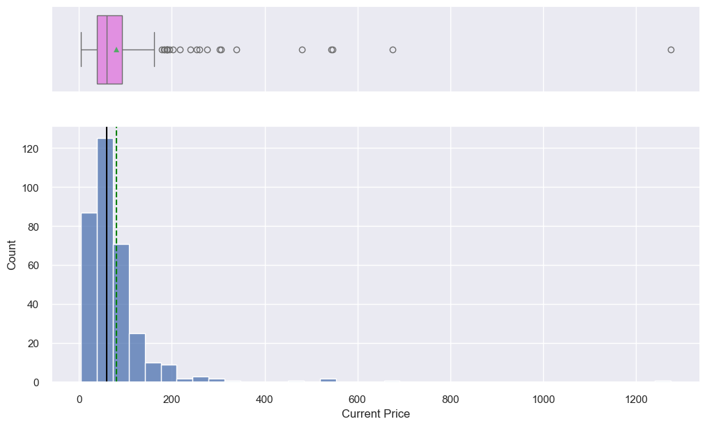

```python
histogram_boxplot(df, 'Current Price')
```

#### Based on the histogram and boxplot for Current Price, the following observations can be made:

##### Spread and Outliers: The boxplot reveals a large number of outliers on the upper end of the price spectrum, confirming that while most stocks fall within a typical and relatively narrow price range, a handful of companies have exceptionally high current prices that pull the mean upward and widen the overall spread.

### Price Change

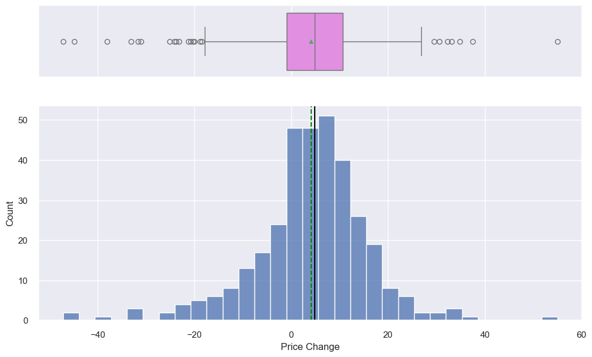

```python
histogram_boxplot(df, 'Price Change')
```

#### Based on the histogram and boxplot for Price Change, the following observations can be made:

##### Spread and Outliers: The boxplot reveals that while most price changes are clustered tightly around the center, several outliers are present on both the positive and negative ends of the distribution. These outliers represent stocks that experienced unusually large gains or losses, which may be attributable to significant company-specific events, broader market movements, or sector-level volatility.

### Volatility

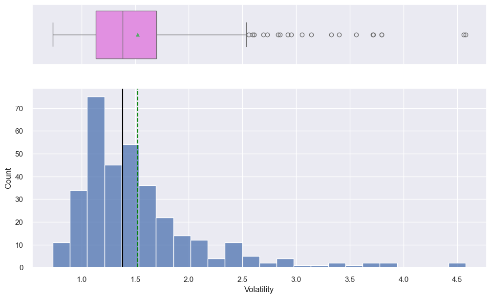

```python
histogram_boxplot(df, 'Volatility')
```

#### Based on the histogram and boxplot for Volatility, the following observations can be made:

##### Distribution Shape: The distribution of Volatility is moderately right-skewed, with the bulk of stocks concentrated at the lower end of the volatility spectrum and a long tail extending toward higher values. The majority of stocks record a volatility score between 1.0 and 1.7, representing the typical risk level within this dataset, while a smaller segment exhibits significantly higher price fluctuations.

##### Central Tendency: The mean (green dashed line) is slightly higher than the median (black solid line), which is consistent with the right-skewed nature of the distribution. This divergence indicates that a small number of highly volatile stocks are pulling the average upward, making the median a more representative measure of the typical volatility level across the dataset.

##### Spread and Outliers: The boxplot reveals numerous outliers on the upper end of the volatility scale, with the highest observed volatility exceeding 4.5. These outliers represent a distinct segment of stocks with exceptionally high price fluctuations, which may be attributable to elevated risk profiles, company-specific events, or particular market conditions affecting these assets. Their presence warrants careful consideration during modeling, as they have the potential to disproportionately influence model performance if left unaddressed.

### ROE

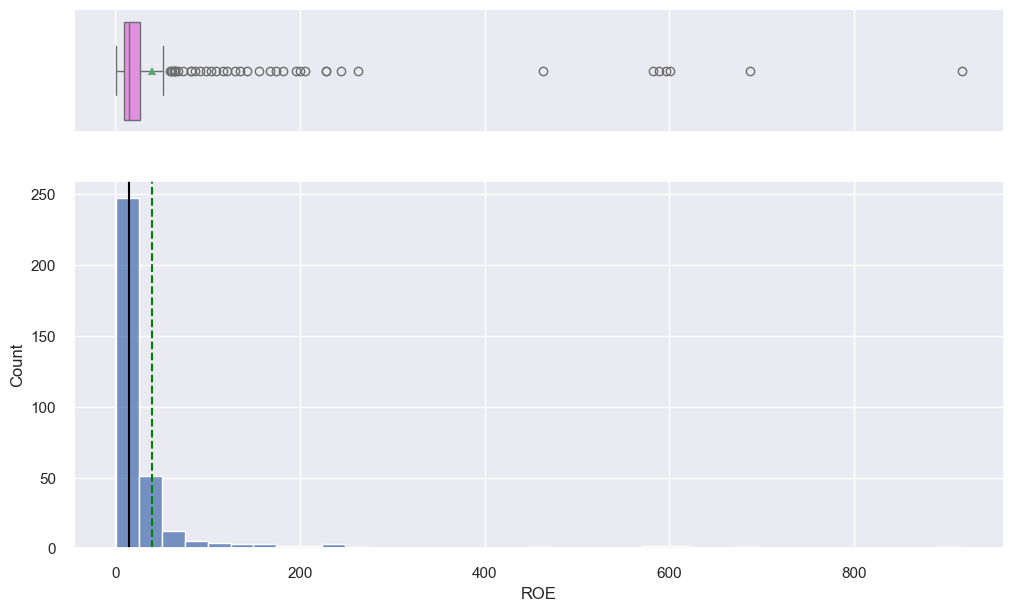

```python
histogram_boxplot(df, 'ROE')
```

### Cash Ratio

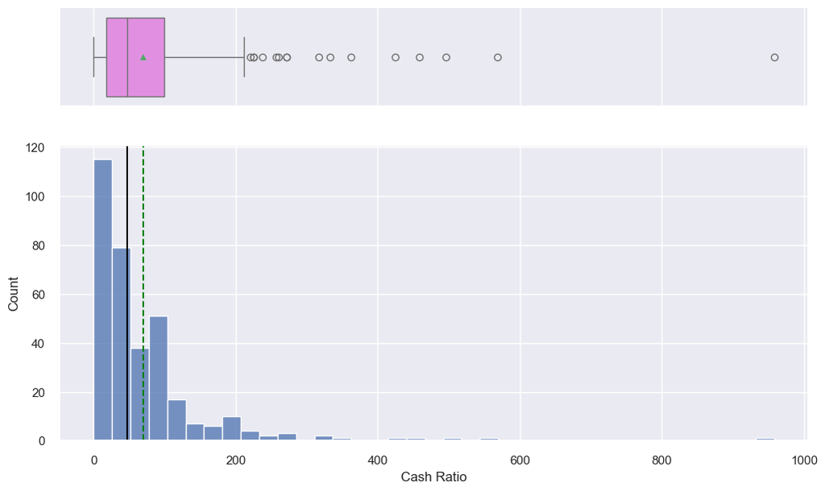

```python
histogram_boxplot(df, 'Cash Ratio')
```

#### Based on the histogram and boxplot for Cash Ratio, the following observations can be made:

##### Distribution Shape: The distribution of Cash Ratio continues the trend of strong right-skewness observed across several other financial metrics in this dataset. The vast majority of companies maintain a low cash ratio, with a massive concentration of values in the lowest bin, while a long tail extends toward exceptionally high values. This indicates that while most companies operate with modest cash reserves relative to their liabilities, a small number maintain extraordinarily high liquidity positions that severely distort the overall distribution.

##### Central Tendency: The median (black solid line) is significantly lower than the mean (green dashed line), which is characteristic of a heavily right-skewed distribution. This substantial divergence confirms that the mean is being pulled considerably upward by a small number of extremely high-value outliers, making the median a far more reliable representation of the typical cash ratio level across the dataset.

##### Spread and Outliers: The boxplot reveals numerous outliers on the upper end of the Cash Ratio spectrum, beginning from approximately 200 and extending to a maximum of nearly 958 — more than twenty times the median value. These extreme outliers represent companies sitting on disproportionately large cash reserves relative to their liabilities, likely reflecting an exceptionally conservative financial strategy, recent large-scale asset disposals, or specific liquidity management practices.

### Net Cash Flow

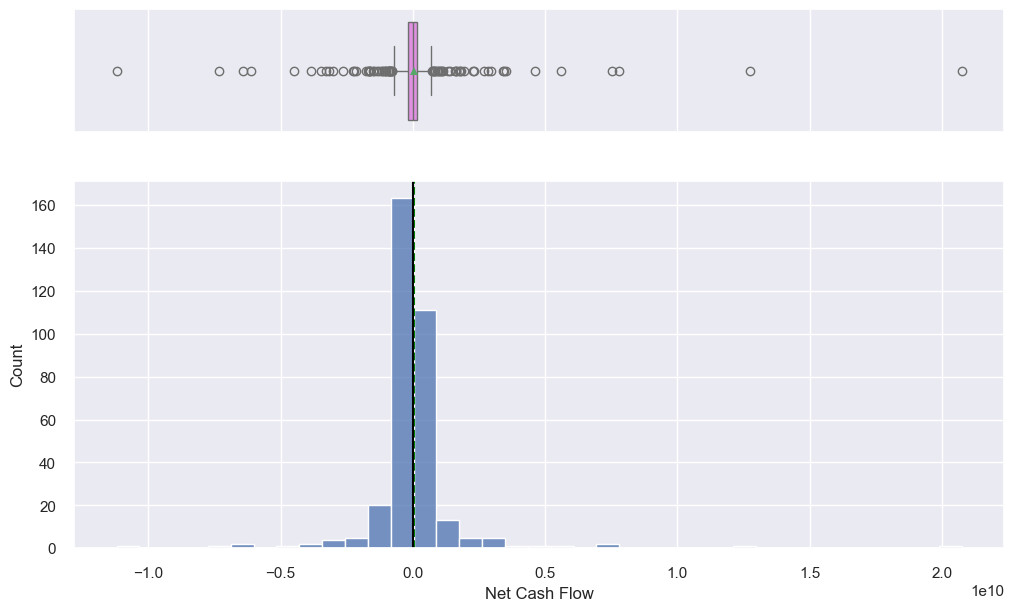

```python
histogram_boxplot(df, 'Net Cash Flow')
```

#### Based on the histogram and boxplot for Net Cash Flow, the following observations can be made:

##### Distribution Shape: Unlike the heavily right-skewed distributions observed across several other financial metrics in this dataset, the Net Cash Flow distribution exhibits a distinctly different pattern — characterized by an exceptionally tall and narrow peak centered around zero, with extreme tails extending in both directions. The vast majority of companies record a net cash flow very close to zero, while a small number of companies operate on a dramatically different financial scale, generating or consuming cash flows in the tens of billions.

##### Central Tendency: The mean (green dashed line) and median (black solid line) are nearly identical and both centered around zero, indicating a roughly symmetric distribution for the core data. This close alignment between the two measures of central tendency is notable, as it contrasts sharply with the heavily skewed distributions observed in features such as ROE and Cash Ratio. However, while the central tendency measures suggest symmetry, they do not fully capture the extreme variability present at both ends of the distribution, and should therefore be interpreted alongside the spread and outlier analysis below.

##### Spread and Outliers: The boxplot reveals a significant number of outliers in both directions. Some companies record massive negative net cash flows as low as -1.12 × 10¹⁰, while others record massive positive net cash flows as high as 2.07 × 10¹⁰ — a scale of tens of billions of dollars. These extreme values likely represent large corporations engaged in significant capital investments, major divestitures, substantial debt financing activities, or exceptional operating performance. The presence of outliers on both ends confirms that while most companies manage their cash flows within a relatively tight range, a small number of financial giants in the dataset are operating on an entirely different scale.

### Net Income

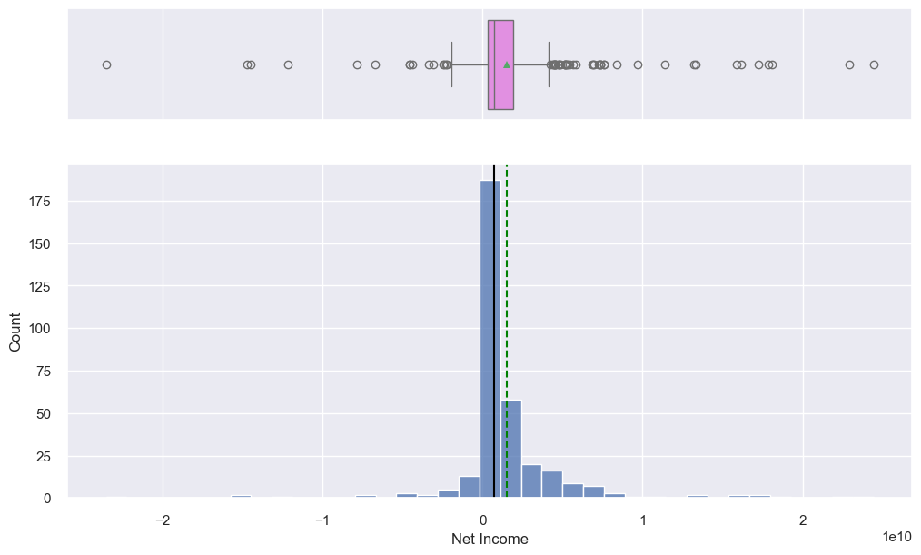

```python
histogram_boxplot(df, 'Net Income')
```

#### Based on the histogram and boxplot for Net Income, the following observations can be made:

##### Distribution Shape: The distribution of Net Income closely mirrors that of Net Cash Flow, exhibiting a sharply concentrated peak near zero with extreme tails extending in both directions. The vast majority of companies record net income figures clustered tightly around zero, reflecting modest profitability for the typical company in the dataset. However, the distribution spans a wide range — from approximately -24 billion to +24 billion — confirming the presence of both heavily loss-making companies and exceptionally profitable corporations operating on a dramatically larger financial scale than the majority.

##### Central Tendency: The median (black solid line) sits close to the peak of the distribution, representing the performance of the typical company in the dataset. The mean (green dashed line), however, is pulled noticeably to the right by high-performing positive outliers, creating a divergence between the two measures of central tendency. While both measures are broadly positive and near zero, neither fully captures the extent of variability present at the extremes of the distribution, and should therefore be interpreted in conjunction with the spread and outlier analysis below.

##### Spread and Outliers: The boxplot reveals extreme outliers at both ends of the spectrum. On the negative end, some companies record losses as severe as approximately -2.4 × 10¹⁰, representing businesses experiencing significant financial distress, heavy write-offs, or substantial operating losses. On the positive end, certain highly profitable corporations record net income figures exceeding +2.4 × 10¹⁰, reflecting strong market performance, favorable industry dynamics, or exceptional profitability driven by scale advantages. These extreme values confirm that while most companies in the dataset operate within a relatively modest income range, a small number of financial giants sit at the far ends of the distribution.

### Earnings Per Share

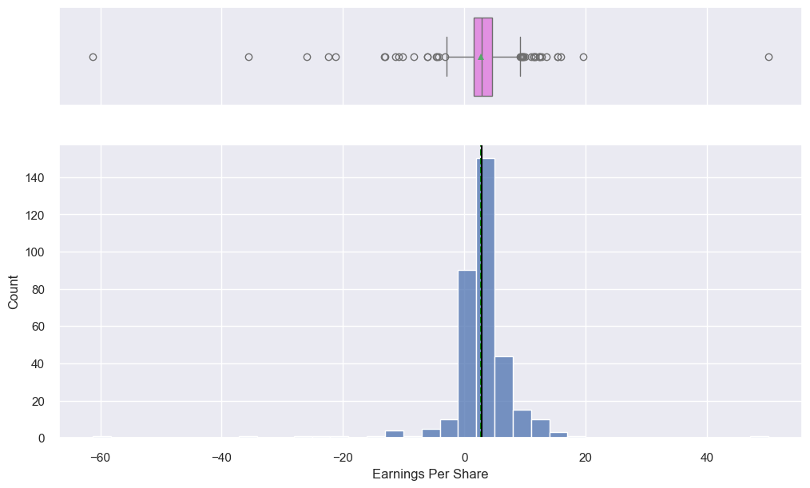

```python
histogram_boxplot(df, 'Earnings Per Share')
```

### Estimated Shares Outstanding

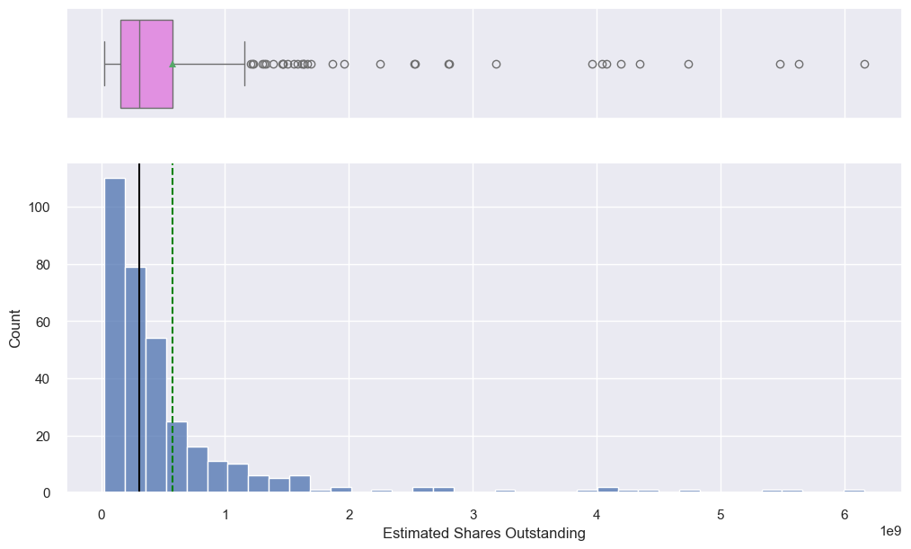

```python
histogram_boxplot(df, 'Estimated Shares Outstanding')
```

#### Based on the histogram and boxplot for Estimated Shares Outstanding, the following observations can be made:

##### Distribution Shape: The distribution of Estimated Shares Outstanding is heavily right-skewed, continuing the pattern of extreme skewness observed across several other financial metrics in this dataset. The vast majority of companies have a relatively modest number of shares outstanding, with values concentrated tightly at the lower end of the distribution. A long tail extends toward extraordinarily high values, reflecting the presence of a small number of large corporations whose share counts dwarf those of the typical company in the dataset. It is worth noting that the x-axis scale is expressed in billions (1e9), underscoring the massive disparity in scale between mid-sized firms and the largest market players.

##### Central Tendency: The median (black solid line) is significantly lower than the mean (green dashed line), which is characteristic of a heavily right-skewed distribution. This substantial divergence confirms that the mean is being pulled considerably upward by a small number of mega-cap companies with an enormous number of shares outstanding, making the median a far more reliable representation of the typical share count across the dataset.

##### Spread and Outliers: The boxplot reveals a significant concentration of outliers on the upper end of the Estimated Shares Outstanding spectrum, with some companies exceeding 6 × 10⁹ (6 billion) shares outstanding — a figure that confirms the extreme disparity between the largest and most typical companies in the dataset. These outliers likely represent very large market capitalization corporations with complex capital structures, a long history of share issuance, or specific corporate governance arrangements that result in exceptionally high share counts. Their presence introduces considerable variance into this feature and warrants careful treatment prior to clustering.

### P/E Ratio

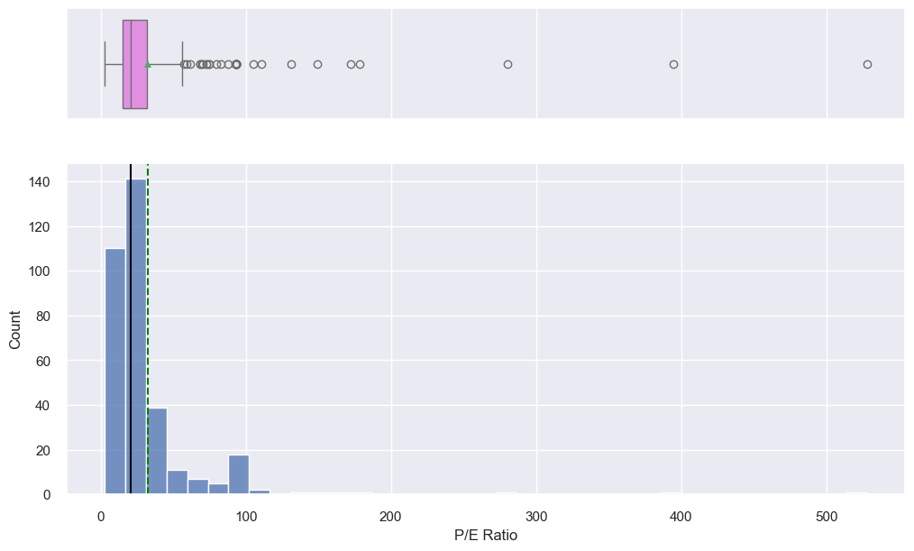

```python
histogram_boxplot(df, 'P/E Ratio')
```

#### Based on the histogram and boxplot for P/E Ratio (Price-to-Earnings), the following observations can be made:

##### Distribution Shape: The distribution of P/E Ratio is heavily right-skewed, with the sharpest concentration of values occurring in the 20–25 range — broadly considered a standard valuation band across many sectors, though this varies by industry. A long tail extends toward much higher values, reflecting a smaller segment of stocks with exceptionally elevated valuations. This pattern confirms that while most companies in the dataset trade at conventional earnings multiples, a distinct group of high-valuation stocks sits well beyond the typical range.

##### Central Tendency: The median (black solid line) is significantly lower than the mean (green dashed line), reinforcing the strong right-skewness of the distribution. The mean is being pulled considerably upward by a small number of companies with extremely high P/E ratios, making it an unreliable measure of typical valuation in this dataset. The median, therefore, provides a far more representative indication of the valuation level of the typical stock in the sample.

##### Spread and Outliers: The boxplot reveals a substantial number of outliers beyond the upper whisker, with some extreme values exceeding a P/E ratio of 100, and the most extreme observation reaching over 528. These outliers likely represent high-growth or potentially overvalued stocks whose future earnings expectations are priced well above their current earnings — a characteristic commonly associated with technology, biotechnology, or early-stage growth companies. The wide range from the lower end of the distribution to the maximum value of 528.04 confirms the extreme disparity in valuations present within this dataset.

### P/B Ratio

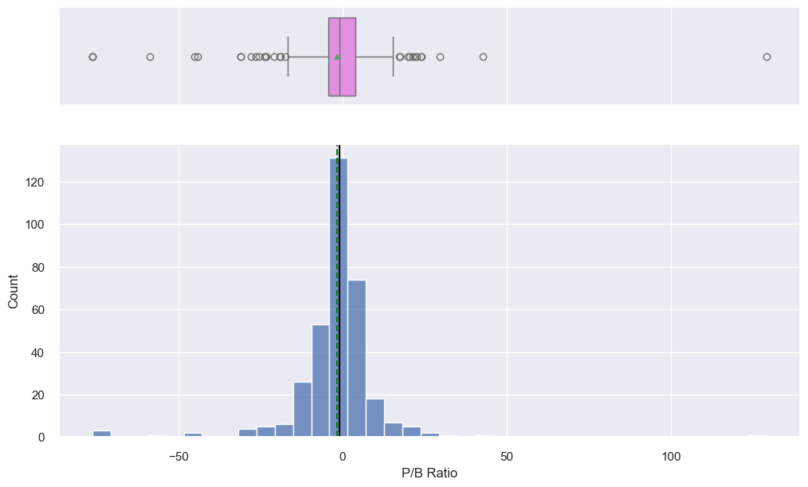

```python
histogram_boxplot(df, 'P/B Ratio')
```

#### Based on the histogram and boxplot for P/B Ratio (Price-to-Book), the following observations can be made:

##### Distribution Shape: Unlike the heavily right-skewed distributions observed across most other financial metrics in this dataset, the P/B Ratio exhibits a relatively symmetric central mass, with the highest frequency of values clustered tightly in the -10 to 10 range and the sharpest concentration occurring around zero. However, this apparent central symmetry is significantly disrupted by extreme outliers at both ends of the distribution, which introduce considerable variance and make the overall distribution more complex to interpret and handle than its central tendency alone would suggest.

##### Central Tendency: The mean (green dashed line) and median (black solid line) are very close to each other, both centered near zero. This close alignment reflects the approximate symmetry of the core distribution and confirms that the typical company in the dataset has a P/B Ratio hovering around zero — indicating that market value and book value are broadly comparable for most stocks. However, as with Net Cash Flow and EPS, the near-identical mean and median should not be interpreted as an absence of variability, given the presence of extreme outliers at both ends that significantly widen the overall spread.

##### Spread and Outliers: The boxplot reveals significant outliers in both directions. On the negative end, values reach as low as approximately -76.12, representing companies with negative book equity — a situation that commonly arises from accumulated losses, aggressive share repurchase programmes that exceed retained earnings, or specific accounting treatments that reduce the equity base below zero. On the positive end, one extreme outlier reaches over 129.06, likely representing a company with exceptionally strong growth prospects, significant intangible assets not fully reflected in book value, or a potential data anomaly that warrants further investigation prior to modeling. The wide range from -76.12 to 129.06 confirms the extreme disparity in Price-to-Book valuations present within this dataset.

```python
# function to create labeled barplots


def labeled_barplot(df, feature, perc=False, n=None):
    """
    Barplot with percentage at the top

    data: dataframe
    feature: dataframe column
    perc: whether to display percentages instead of count (default is False)
    n: displays the top n category levels (default is None, i.e., display all levels)
    """

    total = len(df[feature])  # length of the column
    count = df[feature].nunique()
    if n is None:
        plt.figure(figsize=(count + 1, 5))
    else:
        plt.figure(figsize=(n + 1, 5))

    plt.xticks(rotation=90, fontsize=15)
    ax = sns.countplot(
        data=df,
        x=feature,
        order=df[feature].value_counts().index[:n].sort_values(),
    )

    for p in ax.patches:
        if perc == True:
            label = "{:.1f}%".format(
                100 * p.get_height() / total
            )  # percentage of each class of the category
        else:
            label = p.get_height()  # count of each level of the category

        x = p.get_x() + p.get_width() / 2  # width of the plot
        y = p.get_height()  # height of the plot

        ax.annotate(
            label,
            (x, y),
            ha="center",
            va="center",
            size=12,
            xytext=(0, 5),
            textcoords="offset points",
        )  # annotate the percentage

    plt.show()  # show the plot
```

### GICS Sector

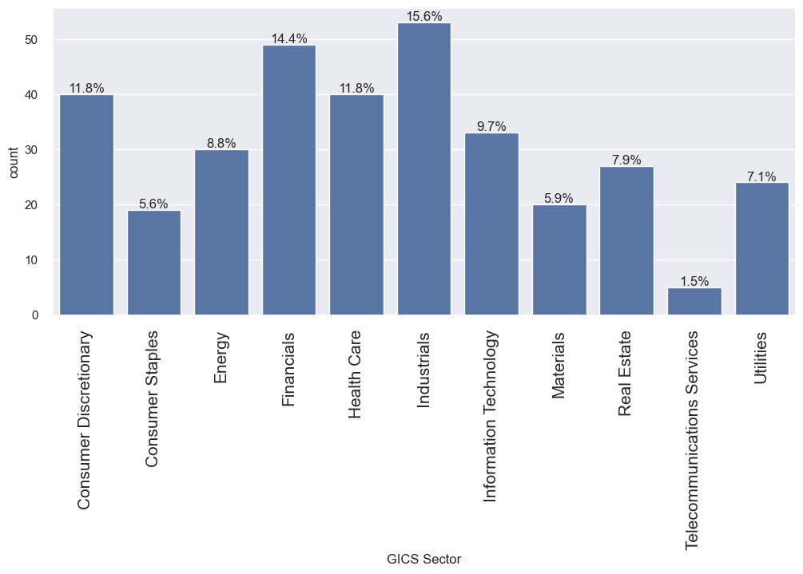

```python
labeled_barplot(df, 'GICS Sector', perc=True)
```

#### Based on the bar plot for GICS Sector, the following observations can be made:

##### Most Represented Sectors: Industrials and Financials are the two most heavily represented sectors in the dataset, accounting for 15.6% and 14.4% of all companies, respectively. Their combined share of approximately 30% suggests that the dataset has a notable concentration in traditional, established industries — a factor worth considering when interpreting clustering outcomes and sector-level patterns.

##### Balanced Representation: Consumer Discretionary and Health Care each account for an identical 11.8% of the dataset, reflecting an equal and balanced presence across these two economically significant sectors. This parity is noteworthy and suggests that both sectors are proportionally well-represented relative to their broader market significance.

##### Least Represented Sector: Telecommunications Services is the most sparsely represented sector in the dataset, accounting for only 1.5% of all companies. This minimal presence suggests that the dataset offers limited coverage of the telecommunications industry, which may restrict the model's ability to draw meaningful conclusions about this sector during clustering and analysis.

### GICS Sub Industry

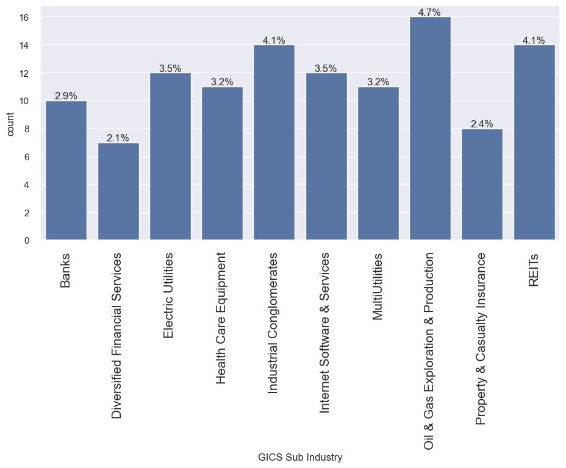

```python
labeled_barplot(df, 'GICS Sub Industry', perc=True, n=10)
```

## Bivariate Analysis

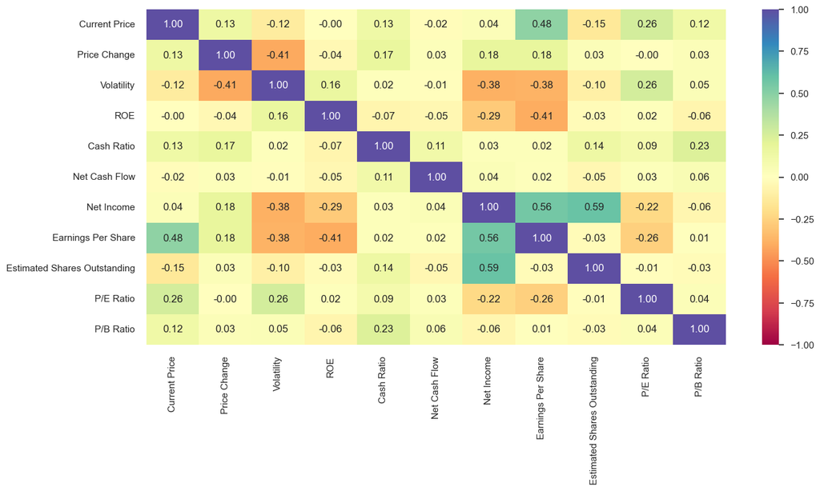

```python
# correlation check
plt.figure(figsize=(15, 7))
sns.heatmap(
    df.select_dtypes(include=['number']).corr(),
    annot=True,
    vmin=-1, vmax=1,
    fmt=".2f",
    cmap="Spectral"
)
plt.show()
```

#### Based on the correlation heatmap, the following observations can be made:

#### Positive Correlations:

##### Current Price & Earnings Per Share (0.48): A moderate positive relationship between current stock price and earnings per share suggests that stocks with higher per-share earnings tend to command higher market prices. This is consistent with fundamental valuation theory, whereby stronger earnings performance is typically rewarded with higher market valuations.

#### Notable Negative Correlations:

##### Price Change & Volatility (-0.41): A moderate inverse relationship between price change and volatility suggests that stocks experiencing stronger price appreciation tend to exhibit lower volatility, while highly volatile stocks may struggle to sustain consistent positive price movements.

##### ROE & Earnings Per Share (-0.41): An interesting and somewhat counterintuitive inverse relationship exists between Return on Equity and Earnings Per Share in this dataset. This may indicate that high-EPS stocks in this group tend to have larger equity bases, which dilutes the ROE percentage despite strong absolute earnings — a nuance worth bearing in mind when interpreting these two metrics independently during modeling.

##### Volatility & Net Income (-0.38): A moderate negative relationship between volatility and net income suggests that more profitable companies tend to exhibit lower stock price volatility.

#### Largely Independent Variables:

##### Net Cash Flow: This metric exhibits near-zero correlation with the majority of other variables in the dataset, with all correlation values falling between -0.05 and 0.11. This confirms that Net Cash Flow captures unique financial information that is not redundant with income or price metrics, and reinforces its value as an independent feature in the clustering model.

##### P/E and P/B Ratios: Both valuation ratios are largely uncorrelated with the other fundamental performance metrics in this dataset, suggesting that market-based valuation multiples move independently of the underlying operational and financial performance indicators captured by the remaining features.

### Let's check the stocks of which economic sector have seen the maximum price increase on average.

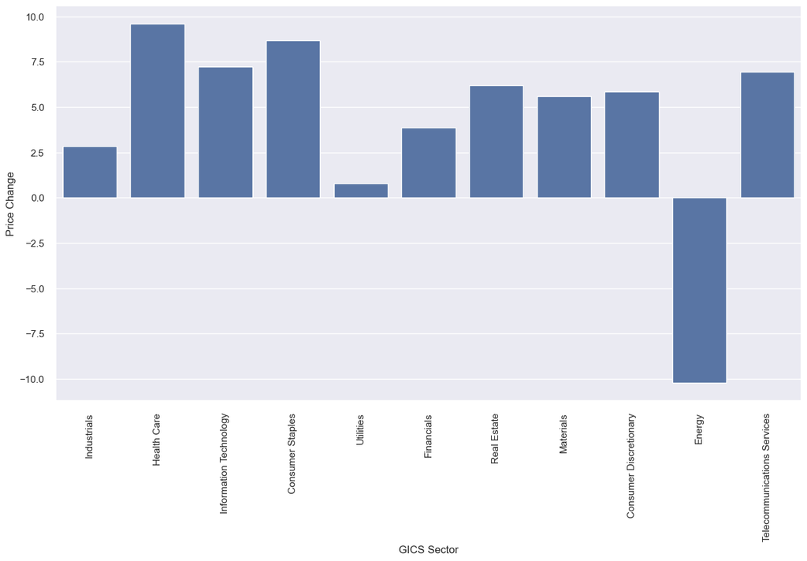

```python
plt.figure(figsize=(15,8))
# 'GICS Sector' on the x-axis and 'Price Change' on the y-axis
sns.barplot(data=df, x='GICS Sector', y='Price Change', errorbar=None)
plt.xticks(rotation=90)
plt.show()
```

#### Based on the bar plot of Price Change by GICS Sector, the following observations can be made:

##### Top Performer — Health Care: The Health Care sector records the highest average price increase of nearly 10%, making it the standout performer across all sectors during the observed period. This strong appreciation likely reflects sustained investor confidence in the sector.

##### Strong Growth — Consumer Staples and Information Technology: Consumer Staples and Information Technology both record average price increases significantly above the overall market mean, positioning them as the next strong-performing sectors, respectively. Their above-average performance reflects the resilience of essential consumer goods demand and the continued structural growth of technology-driven industries.

##### Defensive Sectors — Telecommunications Services and Real Estate: Telecommunications Services and Real Estate deliver solid positive average returns, though both trail the leading sectors.

##### Moderate Growth — Consumer Discretionary, Materials, Financials, and Industrials: All post positive average price changes within a moderate range.

##### Laggard — Utilities: The Utilities sector records the lowest positive average price change among the sectors that remained in positive territory, with performance close to flat.

##### Negative Performer — Energy: The Energy sector is the only sector to record a negative average price change, declining by approximately -10% during the observed period. This underperformance stands in sharp contrast to the rest of the market

### Cash ratio provides a measure of a company's ability to cover its short-term obligations using only cash and cash equivalents. Let's see how the average cash ratio varies across economic sectors.

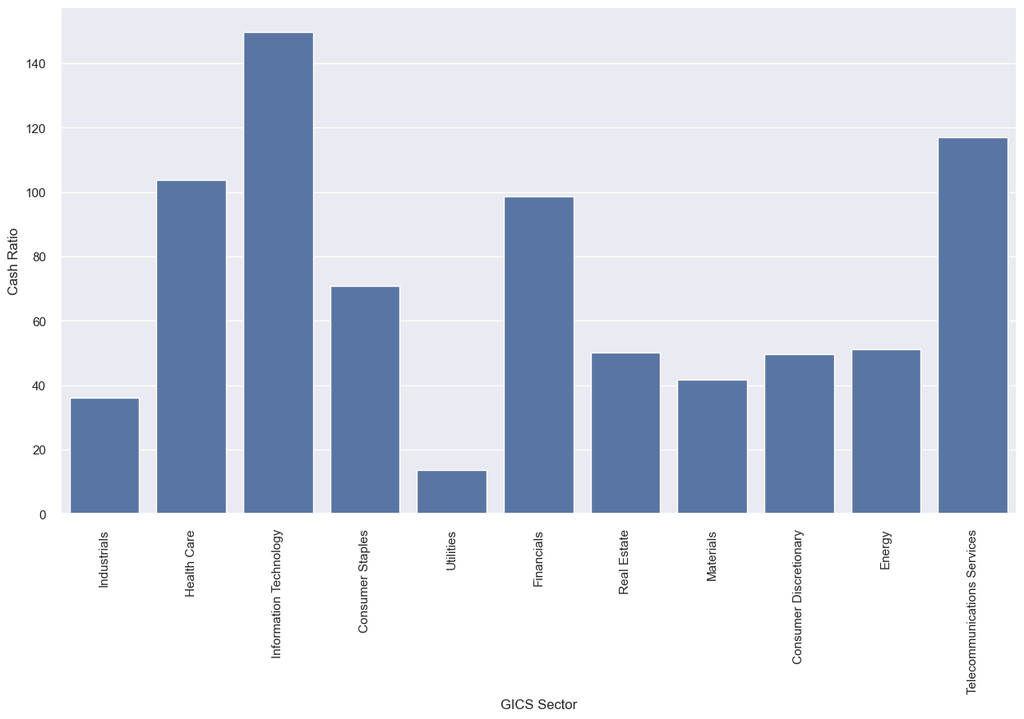

```python
plt.figure(figsize=(15,8))
sns.barplot(data=df, x='GICS Sector', y='Cash Ratio', errorbar=None)
plt.xticks(rotation=90)
plt.show()
```

#### Based on the bar plot of Cash Ratio by GICS Sector, the following observations can be made:

##### Highest Cash Ratio — Information Technology: The Information Technology sector records the highest average cash ratio by a significant margin, considerably exceeding all other sectors.

##### Telecommunications Services and Health Care: Telecommunications Services and Health Care both maintain notably high average cash ratios, reflecting a strong capacity to cover short-term liabilities. In the case of Health Care, this may reflect the capital-intensive nature of research and development activities that require readily accessible cash reserves, while Telecommunications companies may hold higher cash balances to fund ongoing infrastructure investments and regulatory obligations.

##### Solid Cash Position — Financials: The Financials sector maintains a solid average cash ratio, which is broadly expected given the critical importance of liquidity management and capital adequacy in banking and financial services. Maintaining sufficient cash reserves is not merely a strategic choice for financial institutions but is often a regulatory requirement.

##### Moderate Cash Ratios — Industrials, Materials, and Energy: Industrials, Materials, and Energy sectors maintain moderate average cash ratios, reflecting the need to balance immediate liquidity with significant ongoing investments in physical assets, equipment, and operations.

##### Lowest Cash Ratio — Utilities: The Utilities sector records the lowest average cash ratio across all sectors. This is broadly expected, as utility companies typically operate with highly predictable and regulated cash flows, reducing the need to hold large amounts of idle cash.

### P/E ratios can help determine the relative value of a company's shares as they signify the amount of money an investor is willing to invest in a single share of a company per dollar of its earnings. Let's see how the P/E ratio varies, on average, across economic sectors.

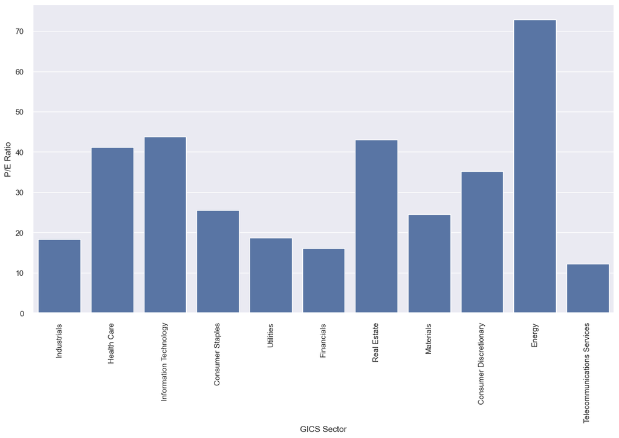

```python
plt.figure(figsize=(15,8))
# Set x to 'GICS Sector' and y to 'P/E Ratio'
sns.barplot(data=df, x='GICS Sector', y='P/E Ratio', errorbar=None)
plt.xticks(rotation=90)
plt.show()
```

### Volatility accounts for the fluctuation in the stock price. A stock with high volatility will witness sharper price changes, making it a riskier investment. Let's see how volatility varies, on average, across economic sectors.

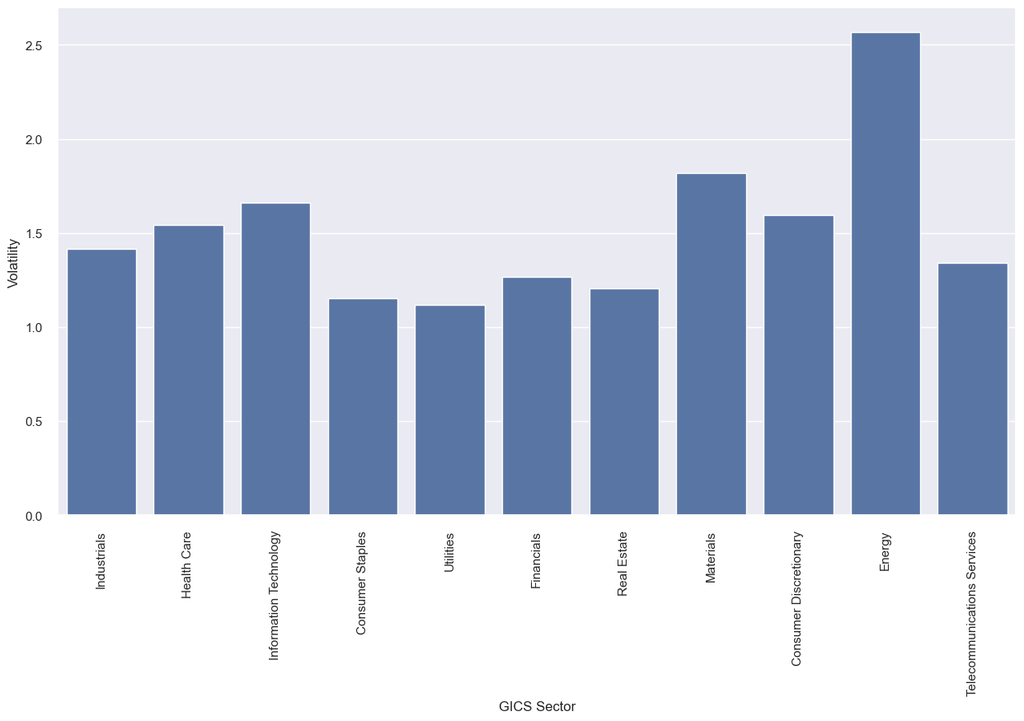

```python
plt.figure(figsize=(15,8))
# Set x to 'GICS Sector' and y to 'Volatility'
sns.barplot(data=df, x='GICS Sector', y='Volatility', errorbar=None)
plt.xticks(rotation=90)
plt.show()
```

#### Based on the bar plot of Volatility by GICS Sector, the following observations can be made:

##### Most Volatile — Energy: The Energy sector exhibits the highest average volatility by a significant margin, establishing it as the riskiest investment group in this dataset.

##### High Risk — Materials and Information Technology: Materials and Information Technology record the second and third highest average volatility levels, respectively. For Materials, elevated volatility is typically driven by the cyclical nature of commodity prices and the sensitivity of raw material demand to broader economic conditions. For Information Technology, rapid innovation cycles, competitive disruption, and sensitivity to interest rate expectations collectively contribute to above-average price fluctuations.

##### Moderate Risk — Consumer Discretionary, Health Care, and Industrials: Consumer Discretionary, Health Care, and Industrials occupy the middle range of the volatility distribution, recording moderate average price fluctuations.

##### Stable Sectors — Utilities, Consumer Staples, and Real Estate: Utilities, Consumer Staples, and Real Estate record among the lowest average volatility levels across all sectors, consistent with their well-established reputations as defensive sectors.

## Data Preprocessing

### Outlier Check

#### Let's plot the boxplots of all numerical columns to check for outliers.

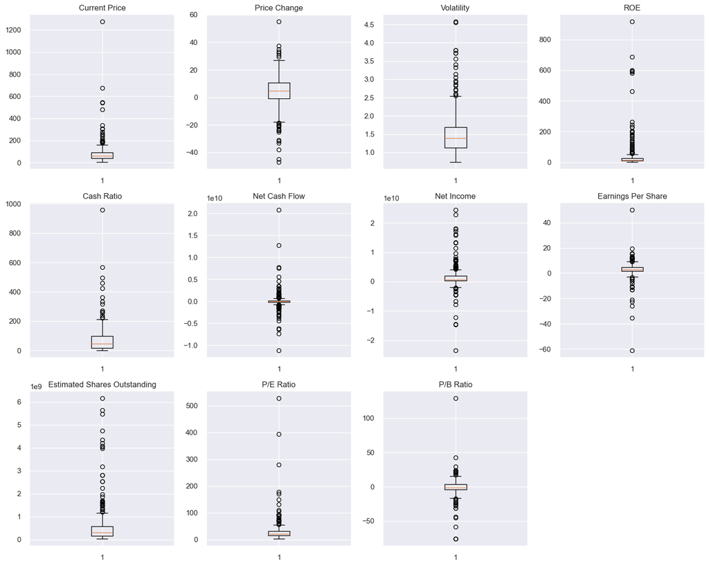

```python
plt.figure(figsize=(15, 12))

numeric_columns = df.select_dtypes(include=np.number).columns.tolist()

for i, variable in enumerate(numeric_columns):
    plt.subplot(3, 4, i + 1)
    plt.boxplot(df[variable], whis=1.5)
    plt.tight_layout()
    plt.title(variable)

plt.show()
```

### Scaling

#### Let's scale the data before we proceed with clustering.

```python
# Scaling the data before clustering
scaler = StandardScaler()

# Select only numerical columns for the subset
subset = df.select_dtypes(include=np.number)

# Fit and transform the numerical data
subset_scaled = scaler.fit_transform(subset)
```

```python
# creating a dataframe of the scaled data
subset_scaled_df = pd.DataFrame(subset_scaled, columns=subset.columns)
```

## K-means Clustering

### Checking Elbow Plot

```python
k_means_df = subset_scaled_df.copy()
```

```
Number of Clusters: 1 	Average Distortion: 2.5425069919221697
Number of Clusters: 2 	Average Distortion: 2.3862098789299604
Number of Clusters: 3 	Average Distortion: 2.33620927590848
Number of Clusters: 4 	Average Distortion: 2.2190505638334423
Number of Clusters: 5 	Average Distortion: 2.133404401901685
Number of Clusters: 6 	Average Distortion: 2.0815036860937144
Number of Clusters: 7 	Average Distortion: 2.0045413402786814
Number of Clusters: 8 	Average Distortion: 1.986423782487441
Number of Clusters: 9 	Average Distortion: 1.956222103389025
Number of Clusters: 10 	Average Distortion: 1.9360473996664198
Number of Clusters: 11 	Average Distortion: 1.8615942883461607
Number of Clusters: 12 	Average Distortion: 1.8219574388532505
Number of Clusters: 13 	Average Distortion: 1.7936924742607907
Number of Clusters: 14 	Average Distortion: 1.7567842179093438
```

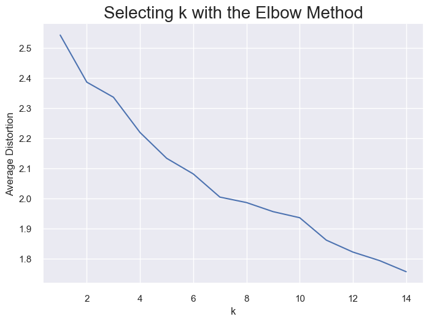

```python
clusters = range(1, 15)
meanDistortions = []

for k in clusters:
    model = KMeans(n_clusters=k, random_state=1)
    model.fit(subset_scaled_df)
    prediction = model.predict(k_means_df)
    distortion = (
        sum(np.min(cdist(k_means_df, model.cluster_centers_, "euclidean"), axis=1))
        / k_means_df.shape[0]
    )

    meanDistortions.append(distortion)

    print("Number of Clusters:", k, "\tAverage Distortion:", distortion)

plt.plot(clusters, meanDistortions, "bx-")
plt.xlabel("k")
plt.ylabel("Average Distortion")
plt.title("Selecting k with the Elbow Method", fontsize=20)
plt.show()
```

#### Based on the Elbow Method and Average Distortion plots, the following observations can be made regarding the optimal number of clusters for this dataset:

##### Initial Significant Drops: The most pronounced reductions in distortion occur as k moves from 1 to 4, indicating that transitioning from a single group to four distinct clusters captures a substantial portion of the data's underlying structure. Each additional cluster in this range contributes meaningfully to reducing the average distance between data points and their assigned centers, confirming that the data contains at least four genuinely distinct groupings.

##### Identifying the Elbow: The distortion curve begins to level off noticeably after k = 4, with a secondary inflection point observable around k = 7. These two values represent the most defensible elbow points in the curve — the stages at which the marginal benefit of adding an additional cluster diminishes most clearly relative to the preceding reductions.

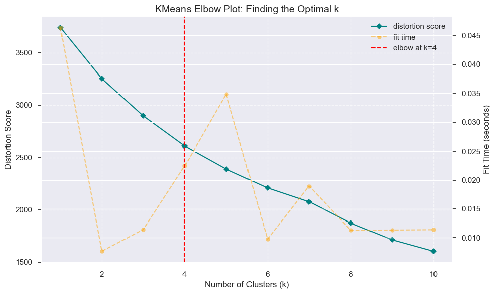

```python
import matplotlib.pyplot as plt
import time
from sklearn.cluster import KMeans

# 1. Define the range of clusters to test
clusters = range(1, 11)
distortions = []
fit_times = []

# 2. Calculate Distortion (Inertia) and Fit Time for each k
for k in clusters:
    model = KMeans(n_clusters=k, n_init=10, random_state=1)

    start_time = time.time()
    model.fit(k_means_df)
    end_time = time.time()

    distortions.append(model.inertia_)
    fit_times.append(end_time - start_time)

# 3. Plotting the results (Manually recreating the KElbowVisualizer look)
fig, ax1 = plt.subplots(figsize=(10, 6))

# Plot Distortion Score (Teal)
ax1.plot(clusters, distortions, 'D-', color='teal', label='distortion score')
ax1.set_xlabel('Number of Clusters (k)')
ax1.set_ylabel('Distortion Score')
ax1.set_title('KMeans Elbow Plot: Finding the Optimal k', fontsize=14)
ax1.grid(True, linestyle='--', alpha=0.6)

# Plot Fit Time (Orange) on a twin axis
ax2 = ax1.twinx()
ax2.plot(clusters, fit_times, 'o--', color='orange', alpha=0.5, label='fit time')
ax2.set_ylabel('Fit Time (seconds)')

# Add a vertical line at the 'elbow' (k=4)
plt.axvline(x=4, color='red', linestyle='--', label='elbow at k=4')

# Combine legends from both axes
lines, labels = ax1.get_legend_handles_labels()
lines2, labels2 = ax2.get_legend_handles_labels()
ax1.legend(lines + lines2, labels + labels2, loc='upper right')

plt.tight_layout()
plt.show()
```

#### Based on the Elbow Method and Average Distortion plots, the following observations can be made regarding the optimal number of clusters for this dataset:

##### Decreasing Distortion: As the number of clusters k increases, the average distortion — measured as the sum of squared distances from each data point to its assigned cluster center — decreases consistently, as expected. This reflects the fundamental principle that adding more clusters always reduces the within-cluster variance, since each additional center is able to capture a more granular subset of the data.

##### Initial Significant Drops: The most pronounced reductions in distortion occur as k moves from 1 to 4, indicating that transitioning from a single group to four distinct clusters captures a substantial portion of the data's underlying structure. Each additional cluster in this range contributes meaningfully to reducing the average distance between data points and their assigned centers, confirming that the data contains at least four genuinely distinct groupings.

##### Identifying the Elbow: The distortion curve begins to level off noticeably after k = 4, with a secondary inflection point observable around k = 7. These two values represent the most defensible elbow points in the curve — the stages at which the marginal benefit of adding an additional cluster diminishes most clearly relative to the preceding reductions.

##### Risk of Over-Clustering: While distortion continues to decrease as k increases beyond 7, selecting a very high value of k — such as 12 or 14 — risks over-clustering, whereby groups become too small, too granular, or too difficult to interpret meaningfully in the context of financial stock analysis. In such cases, the additional clusters may reflect noise or minor variations rather than genuinely distinct financial archetypes.

##### Recommended Number of Clusters: Based on the Elbow Method analysis, two values of k emerge as strong candidates: k = 4 is recommended for broad segmentation, providing a high-level classification of stocks into a small number of meaningful financial archetypes — such as Value, Growth, Risk, and Mega-Cap profiles — that are both interpretable and actionable for financial analysis. k = 7 may be more appropriate if a more granular breakdown of niche stock behaviors is desired, offering additional differentiation within the broader groupings identified at k = 4 without crossing into the territory of over-clustering.

### Let's check the silhouette scores

```
For n_clusters = 2, the silhouette score is 0.45335782729503565)
For n_clusters = 3, the silhouette score is 0.40374060030338865)
For n_clusters = 4, the silhouette score is 0.4246430808437099)
For n_clusters = 5, the silhouette score is 0.4381539778147092)
For n_clusters = 6, the silhouette score is 0.40869599703024256)
For n_clusters = 7, the silhouette score is 0.1207450219233897)
For n_clusters = 8, the silhouette score is 0.3693991650696542)
For n_clusters = 9, the silhouette score is 0.35185096182499204)
For n_clusters = 10, the silhouette score is 0.32950073703610283)
For n_clusters = 11, the silhouette score is 0.1486586842527321)
For n_clusters = 12, the silhouette score is 0.15784241071085106)
For n_clusters = 13, the silhouette score is 0.15646997458716602)
For n_clusters = 14, the silhouette score is 0.16253506827999134)
```

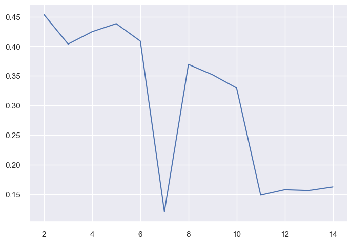

```python
sil_score = []
cluster_list = range(2, 15)
for n_clusters in cluster_list:
    clusterer = KMeans(n_clusters=n_clusters, random_state=1)
    preds = clusterer.fit_predict((subset_scaled_df))
    score = silhouette_score(k_means_df, preds)
    sil_score.append(score)
    print("For n_clusters = {}, the silhouette score is {})".format(n_clusters, score))

plt.plot(cluster_list, sil_score)
plt.show()
```

#### Based on the Silhouette Score analysis, the following observations can be made regarding the optimal number of clusters for this dataset:

##### Actionable Investment Archetypes: A five-cluster solution enables stocks to be categorized into clear and interpretable investment profiles — such as Growth, Value, Blue Chip, High-Risk, and Mega-Cap — providing a far richer and more actionable framework for financial decision-making than a two-cluster solution could offer.

##### Structural Stability: A silhouette score of 0.4381 is highly respectable for high-dimensional financial data, where clean cluster boundaries are inherently difficult to achieve. This score confirms that the five identified groups are sufficiently well-separated to be considered reliable and meaningful for practical investment analysis and decision-making.

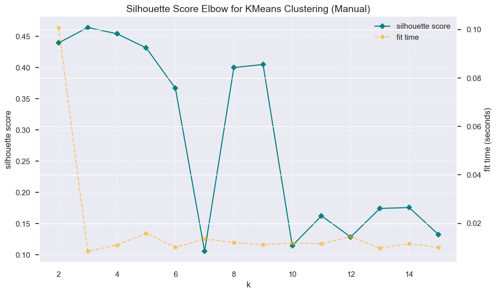

```python
import matplotlib.pyplot as plt
import time
from sklearn.cluster import KMeans
from sklearn.metrics import silhouette_score

# Range of k to evaluate
k_range = range(2, 16)
silhouette_scores = []
fit_times = []

# Manual silhouette score and fit time calculation
for k in k_range:
    model = KMeans(n_clusters=k, n_init=10, random_state=1)

    # Measure fit time
    start = time.time()
    labels = model.fit_predict(k_means_df)
    end = time.time()

    # Measure silhouette score
    score = silhouette_score(k_means_df, labels)

    silhouette_scores.append(score)
    fit_times.append(end - start)

# Visualization of the results
fig, ax1 = plt.subplots(figsize=(10, 6))

# Primary axis for Silhouette Score
ax1.plot(k_range, silhouette_scores, 'D-', color='teal', label='silhouette score')
ax1.set_xlabel('k')
ax1.set_ylabel('silhouette score')
ax1.set_title('Silhouette Score Elbow for KMeans Clustering (Manual)', fontsize=14)
ax1.grid(True, linestyle='--', alpha=0.6)

# Secondary axis for Fit Time
ax2 = ax1.twinx()
ax2.plot(k_range, fit_times, 'o--', color='orange', alpha=0.5, label='fit time')
ax2.set_ylabel('fit time (seconds)')

# Consolidate legends from both axes
lines1, labels1 = ax1.get_legend_handles_labels()
lines2, labels2 = ax2.get_legend_handles_labels()
ax1.legend(lines1 + lines2, labels1 + labels2, loc='upper right')

plt.tight_layout()
plt.show()
```

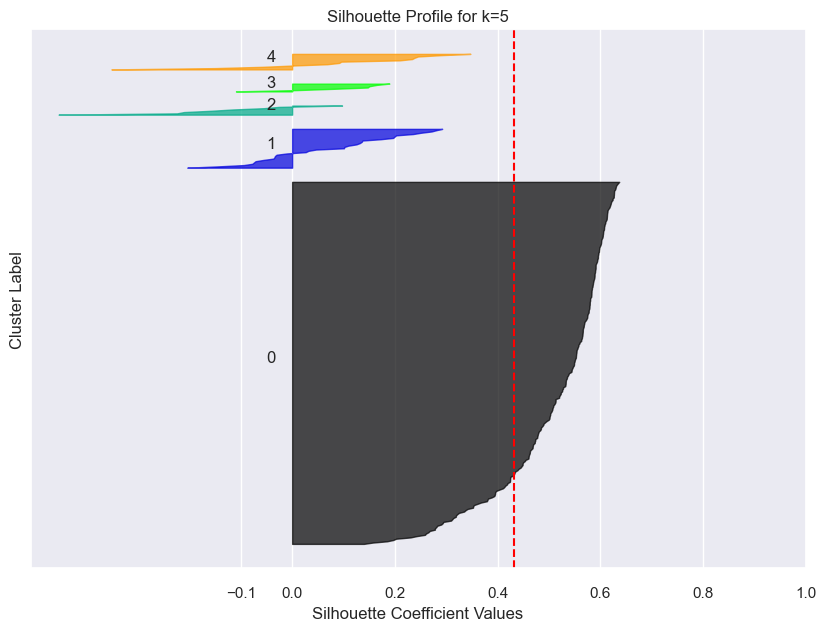

```python
import matplotlib.pyplot as plt
import matplotlib.cm as cm
import numpy as np
from sklearn.metrics import silhouette_samples, silhouette_score
from sklearn.cluster import KMeans

# 1. Setup the Model
n_clusters = 5
model = KMeans(n_clusters=n_clusters, n_init=10, random_state=1)
cluster_labels = model.fit_predict(k_means_df)
silhouette_avg = silhouette_score(k_means_df, cluster_labels)
sample_silhouette_values = silhouette_samples(k_means_df, cluster_labels)

# 2. Create the Visualization
fig, ax1 = plt.subplots(figsize=(10, 7))
y_lower = 10

for i in range(n_clusters):
    # Aggregate and sort silhouette scores for this specific cluster
    ith_cluster_silhouette_values = sample_silhouette_values[cluster_labels == i]
    ith_cluster_silhouette_values.sort()

    size_cluster_i = ith_cluster_silhouette_values.shape[0]
    y_upper = y_lower + size_cluster_i

    # Color mapping
    color = cm.nipy_spectral(float(i) / n_clusters)
    ax1.fill_betweenx(np.arange(y_lower, y_upper), 0, ith_cluster_silhouette_values,
                      facecolor=color, edgecolor=color, alpha=0.7)

    # Label the cluster plots with their numbers
    ax1.text(-0.05, y_lower + 0.5 * size_cluster_i, str(i))

    # Compute the new y_lower for next plot
    y_lower = y_upper + 10

# Formatting the plot
ax1.set_title("Silhouette Profile for k=5")
ax1.set_xlabel("Silhouette Coefficient Values")
ax1.set_ylabel("Cluster Label")

# Add a vertical line for the average silhouette score
ax1.axvline(x=silhouette_avg, color="red", linestyle="--")
ax1.set_yticks([])  # Clear the yaxis labels
ax1.set_xticks([-0.1, 0, 0.2, 0.4, 0.6, 0.8, 1])

plt.show()
```

## Creating Final Model

```python
# final K-means model
# We choose 5 clusters based on silhouette analysis and business utility
kmeans = KMeans(n_clusters=5, n_init=10, random_state=1)
kmeans.fit(k_means_df)
```

```
KMeans(n_clusters=5, n_init=10, random_state=1)
```

```python
# creating a copy of the original data
df1 = df.copy()

# adding kmeans cluster labels to the original and scaled dataframes
k_means_df["KM_segments"] = kmeans.labels_
df1["KM_segments"] = kmeans.labels_
```

### Cluster Profiling

```python
# Grouping the data by cluster labels to create profiles
km_cluster_profile = df1.groupby("KM_segments").mean(numeric_only=True)

# Displaying the resulting profiles
print(km_cluster_profile)
```

```
             Current Price  Price Change  Volatility         ROE  Cash Ratio  \
KM_segments
0                73.642268      5.604746    1.398809   25.071174   65.217082
1                44.533549    -11.758615    2.773054   48.193548   70.032258
2               525.418743      8.811119    1.484593   16.375000  259.000000
3                84.355716      3.854981    1.827670  633.571429   33.571429
4                48.103077      6.053507    1.163964   27.538462   77.230769

             Net Cash Flow    Net Income  Earnings Per Share  \
KM_segments
0             1.956858e+07  1.477792e+09            3.677100
1             1.691992e+08 -2.102800e+09           -5.385484
2             2.582054e+08  1.162642e+09           12.772500
3            -5.684000e+08 -4.968157e+09          -10.841429
4             7.732308e+08  1.411492e+10            3.958462

             Estimated Shares Outstanding   P/E Ratio  P/B Ratio   Cluster
KM_segments
0                            4.358335e+08   23.723142  -2.643991  1.914591
1                            5.282695e+08   96.953796   1.719411  0.935484
2                            4.516659e+08  113.904340  30.234451  0.000000
3                            3.981690e+08   42.284541 -11.589502  1.714286
4                            3.918735e+09   16.098039  -4.253404  2.846154
```

#### Based on the K-Means cluster profile analysis, the following observations can be made regarding the five identified segments and their distinguishing financial characteristics:

##### Cluster 1 — The High-Volatility Underperformers (31 companies): This cluster is defined by the highest average volatility across all five segments (2.77), a significantly negative average price change of approximately -11.76%, and negative net income of approximately -$2.1 billion and EPS of approximately -5.39 — collectively painting a picture of high-risk, loss-making companies with poor recent price performance. The very high P/E ratio of approximately 96.95 is likely a distortion caused by negative or near-zero earnings rather than genuine growth expectations, and should be interpreted with caution. The moderate positive ROE of approximately 48.19 appears counterintuitive given the negative income figures, and may reflect the influence of specific financial structures or a small number of high-ROE companies within the cluster skewing the average upward. These stocks represent a high-risk investment profile with limited near-term return potential based on current fundamentals.

##### Cluster 2 — The High-Price Premium Growth Stocks (8 companies): Despite being the smallest cluster alongside Cluster 3, this group is among the most distinctive in the dataset, characterized by a very high average current price of approximately $525.42 — significantly above all other clusters — and an extremely high P/E ratio of approximately 113.90 and P/B ratio of approximately 30.23. These metrics collectively indicate that the market assigns a substantial premium to these stocks relative to their current earnings and book value, reflecting strong investor expectations for future growth. The very high average cash ratio of approximately 259.00 further distinguishes this cluster, suggesting that these companies maintain exceptionally strong liquidity positions. Positive net cash flow, net income, and EPS figures confirm that, unlike Clusters 1 and 3, these are profitable companies whose high valuations are supported by genuine financial strength rather than speculative interest alone.

##### Cluster 3 — The Distressed High-Risk Companies (7 companies): This cluster represents the most concerning risk profile in the dataset, characterized by significantly negative net cash flow, net income, and EPS — with average net income reaching approximately -$4.9 billion — alongside the lowest average cash ratio of approximately 33.57 and the most deeply negative P/B ratio of approximately -11.59. The exceptionally high average ROE of approximately 633.57 is almost certainly a distortion caused by highly negative or near-zero equity bases rather than genuine operational efficiency, and serves as a red flag rather than a positive signal. The combination of massive financial losses, deeply negative book equity, and elevated volatility of approximately 1.83 identifies these companies as severely financially distressed, with some possible speculative investor interest reflected in the moderate P/E ratio of approximately 42.28. These stocks represent the highest-risk segment in the dataset and warrant extreme caution from an investment perspective.

```python
# Counting the number of securities in each segment
km_cluster_profile["count_in_each_segment"] = (
    df1.groupby("KM_segments")["Ticker Symbol"].count().values
)

# Displaying the updated profile with counts
print(km_cluster_profile)
```

```
             Current Price  Price Change  Volatility         ROE  Cash Ratio  \
KM_segments
0                73.642268      5.604746    1.398809   25.071174   65.217082
1                44.533549    -11.758615    2.773054   48.193548   70.032258
2               525.418743      8.811119    1.484593   16.375000  259.000000
3                84.355716      3.854981    1.827670  633.571429   33.571429
4                48.103077      6.053507    1.163964   27.538462   77.230769

             Net Cash Flow    Net Income  Earnings Per Share  \
KM_segments
0             1.956858e+07  1.477792e+09            3.677100
1             1.691992e+08 -2.102800e+09           -5.385484
2             2.582054e+08  1.162642e+09           12.772500
3            -5.684000e+08 -4.968157e+09          -10.841429
4             7.732308e+08  1.411492e+10            3.958462

             Estimated Shares Outstanding   P/E Ratio  P/B Ratio   Cluster  \
KM_segments
0                            4.358335e+08   23.723142  -2.643991  1.914591
1                            5.282695e+08   96.953796   1.719411  0.935484
2                            4.516659e+08  113.904340  30.234451  0.000000
3                            3.981690e+08   42.284541 -11.589502  1.714286
4                            3.918735e+09   16.098039  -4.253404  2.846154

             count_in_each_segment
KM_segments
0                              281
1                               31
2                                8
3                                7
4                               13
```

#### Based on the K-Means cluster profile analysis, the following observations can be made regarding the five identified segments and their distinguishing financial characteristics:

##### Cluster 0 — The Balanced Performers (281 companies): This is by far the largest cluster in the solution, accounting for the overwhelming majority of stocks in the dataset and representing the broadest and most representative cross-section of market behavior. With a moderate current price of approximately $73.64, moderate volatility of 1.40, and broadly positive net cash flow, net income, and EPS figures, these companies reflect the baseline financial profile of the typical stock in the dataset. The moderate P/E ratio of approximately 23.72 and ROE of approximately 25.07 confirm broadly average valuation and profitability, while the moderate positive price change of approximately 5.60% suggests generally stable recent performance. The negative P/B ratio of approximately -2.64 warrants attention, suggesting that some companies in this cluster may carry accumulated losses or hold book values below their market values. Overall, this cluster serves as the market core reference point against which the more specialized clusters can be meaningfully compared.

##### Cluster 1 — The High-Volatility Underperformers (31 companies): This cluster is defined by the highest average volatility across all five segments (2.77), a significantly negative average price change of approximately -11.76%, and negative net income of approximately -$2.1 billion and EPS of approximately -5.39 — collectively identifying these as high-risk, loss-making companies with poor recent price performance. The very high P/E ratio of approximately 96.95 is almost certainly a distortion caused by negative or near-zero earnings rather than genuine growth expectations, and should be interpreted with caution. The moderate positive ROE of approximately 48.19 appears counterintuitive given the negative income figures, and likely reflects the influence of specific financial structures or a small number of high-ROE outliers within the cluster skewing the average upward. These stocks represent a high-risk investment profile with limited near-term return potential based on current fundamentals.

##### Cluster 2 — The High-Price Premium Growth Stocks (8 companies): This small but highly distinctive cluster is characterized by a very high average current price of approximately $525.42 — significantly above all other clusters — alongside an extremely high P/E ratio of approximately 113.90 and P/B ratio of approximately 30.23. These metrics collectively indicate that the market assigns a substantial premium to these stocks relative to their current earnings and book value, reflecting strong investor expectations for future growth. The very high average cash ratio of approximately 259.00 further distinguishes this cluster, confirming that these companies maintain exceptionally strong liquidity positions. Positive net cash flow, net income, and EPS figures confirm that, unlike Clusters 1 and 3, these are genuinely profitable companies whose elevated valuations are supported by real financial strength rather than speculative interest alone.

##### Cluster 3 — The Distressed High-Risk Companies (7 companies): This cluster represents the most concerning risk profile in the dataset, characterized by significantly negative net cash flow, net income, and EPS — with average net income reaching approximately -$4.9 billion — alongside the lowest average cash ratio of approximately 33.57 and the most deeply negative P/B ratio of approximately -11.59. The exceptionally high average ROE of approximately 633.57 is almost certainly a distortion caused by highly negative or near-zero equity bases rather than genuine operational efficiency, and serves as a red flag rather than a positive signal. The combination of massive financial losses, deeply negative book equity, above-average volatility of approximately 1.83, and a moderate P/E ratio of approximately 42.28 suggests that some residual speculative investor interest may exist in these stocks despite their severely distressed financial condition. These companies represent the highest-risk segment in the dataset and warrant extreme caution from an investment perspective.

```python
km_cluster_profile.style.highlight_max(color="lightgreen", axis=0)
```

| KM_segments | Current Price | Price Change | Volatility | ROE | Cash Ratio | Net Cash Flow | Net Income | Earnings Per Share | Estimated Shares Outstanding | P/E Ratio | P/B Ratio | Cluster | count_in_each_segment |
| --- | --- | --- | --- | --- | --- | --- | --- | --- | --- | --- | --- | --- | --- |
| 0 | 73.642268 | 5.604746 | 1.398809 | 25.071174 | 65.217082 | 19568583.629893 | 1477791896.797153 | 3.677100 | 435833507.534555 | 23.723142 | -2.643991 | 1.914591 | 281 |
| 1 | 44.533549 | -11.758615 | 2.773054 | 48.193548 | 70.032258 | 169199225.806452 | -2102799709.677419 | -5.385484 | 528269475.759355 | 96.953796 | 1.719411 | 0.935484 | 31 |
| 2 | 525.418743 | 8.811119 | 1.484593 | 16.375000 | 259.000000 | 258205375.000000 | 1162641625.000000 | 12.772500 | 451665922.790000 | 113.904340 | 30.234451 | 0.000000 | 8 |
| 3 | 84.355716 | 3.854981 | 1.827670 | 633.571429 | 33.571429 | -568400000.000000 | -4968157142.857142 | -10.841429 | 398169036.442857 | 42.284541 | -11.589502 | 1.714286 | 7 |
| 4 | 48.103077 | 6.053507 | 1.163964 | 27.538462 | 77.230769 | 773230769.230769 | 14114923076.923077 | 3.958462 | 3918734987.169230 | 16.098039 | -4.253404 | 2.846154 | 13 |

#### Based on the K-Means cluster profiling and the highlighted summary statistics, the following observations can be made regarding the defining characteristics of each segment:

#### Highlighted Segment Extremes:

##### The summary table highlights the most extreme value for each key metric across all five clusters, confirming the following segment distinctions:

##### Current Price → Cluster 2 (~$525.42): The Elite Premium group commands the highest average stock price by a significant margin.

##### Net Income → Cluster 4 (~$14.11 billion): The Value Titans record the strongest average profitability across all segments.

##### Volatility → Cluster 1 (~2.77): The High-Volatility Underperformers carry the highest average risk profile.

##### ROE → Cluster 3 (~633.57): The Distressed segment records the most extreme ROE figure, though this almost certainly reflects distorted negative equity rather than genuine operational efficiency.

##### Segment Size → Cluster 0 (281 companies): The Balanced Performers constitute the dominant Market Core, accounting for 82.6% of all stocks in the dataset.

##### Cluster 0 — The Balanced Performers (281 companies): The largest segment by a considerable margin, Cluster 0 represents the broad market baseline. These companies exhibit moderate current prices, moderate volatility, positive but average price changes, and generally profitable financials across net cash flow, net income, and EPS. Their moderate P/E ratio of approximately 23.72 reflects conventional market valuations, while the negative P/B ratio of approximately -2.64 suggests that some companies in this group may carry accumulated losses or hold book values below their market values. As the dominant cluster, this segment provides the most representative picture of typical stock behavior in the dataset and serves as the natural reference point for interpreting the more specialized clusters.

##### Cluster 1 — The High-Volatility Underperformers (31 companies): This segment is defined by the highest average volatility across all clusters (2.77), a significantly negative average price change of approximately -11.76%, and negative net income and EPS — collectively identifying these as high-risk, loss-making companies with poor recent price performance. The very high P/E ratio of approximately 96.95 is a distortion driven by negative or near-zero earnings rather than genuine growth expectations. The moderately positive ROE of approximately 48.19 appears counterintuitive in the context of negative income and likely reflects the influence of specific financial structures or a small number of outliers within the cluster. These stocks represent the highest-risk, lowest near-term return profile among all segments, and are best approached with considerable caution.

##### Cluster 2 — The High-Priced Premium Growth Stocks (8 companies): This small but highly distinctive segment is characterized by the highest average current price of approximately $525.42, very high P/E (113.90) and P/B (30.23) ratios, and a very high average cash ratio of approximately 259.00 — reflecting exceptional liquidity. Positive and strong net cash flow, net income, and EPS figures confirm that these are genuinely profitable companies whose premium valuations are underpinned by real financial strength and strong investor expectations for future growth, rather than speculative interest alone. These stocks are likely to appeal to growth-oriented investors willing to pay a significant premium for quality and future potential.

##### Cluster 3 — The Distressed High-Risk Companies (7 companies): This segment presents the most complex and cautionary risk profile in the dataset. The exceptionally high average ROE of approximately 633.57 is almost certainly an accounting artifact driven by deeply negative book equity rather than genuine operational efficiency, and should be interpreted as a warning signal rather than a positive indicator. This assessment is reinforced by the significantly negative net cash flow, net income, and EPS figures, the most deeply negative P/B ratio of approximately -11.59, and the lowest average cash ratio of approximately 33.57 across all segments. The combination of massive financial losses, negative equity, and above-average volatility identifies these companies as severely financially distressed. Any residual market interest in these stocks likely reflects speculative positioning rather than fundamental investment merit.

##### Cluster 4 — The Value Titans / Large-Cap Low P/E Stocks (13 companies): This segment stands out as the most compelling from a value investing perspective, recording the highest average net income of approximately $14.11 billion, the lowest average P/E ratio of 16.10, and the lowest average volatility of 1.16 across all five clusters. The extremely high average estimated shares outstanding of approximately 3.9 billion confirms their mega-cap status. Despite exceptional profitability and financial stability, these companies trade at conservative earnings multiples — suggesting they may be undervalued relative to their earnings power or represent mature, large-scale businesses that the market prices with modest growth premiums. The negative P/B ratio of approximately -4.25 is consistent with significant share buyback activity or accounting structures that reduce book equity without reflecting financial distress. These stocks are ideally suited to value-oriented, risk-averse investors seeking stable returns from financially robust, large-cap companies.

```python
## Complete the code to print the companies in each cluster
for cl in df1["KM_segments"].unique():
    print("In cluster {}, the following companies are present:".format(cl))
    print(df1[df1["KM_segments"] == cl]["Security"].unique())
    print()
```

```
In cluster 0, the following companies are present:
['American Airlines Group' 'AbbVie' 'Abbott Laboratories'
 'Adobe Systems Inc' 'Archer-Daniels-Midland Co' 'Ameren Corp'
 'American Electric Power' 'AFLAC Inc'
 'American International Group, Inc.' 'Apartment Investment & Mgmt'
 'Assurant Inc' 'Arthur J. Gallagher & Co.' 'Akamai Technologies Inc'
 'Albemarle Corp' 'Alaska Air Group Inc' 'Allstate Corp'
 'Applied Materials Inc' 'AMETEK Inc' 'Affiliated Managers Group Inc'
 'Amgen Inc' 'Ameriprise Financial' 'American Tower Corp A'
 'AutoNation Inc' 'Anthem Inc.' 'Aon plc' 'Amphenol Corp' 'Arconic Inc'
 'Activision Blizzard' 'AvalonBay Communities, Inc.' 'Broadcom'
 'American Water Works Company Inc' 'American Express Co' 'Boeing Company'
 'Baxter International Inc.' 'BB&T Corporation' 'Bard (C.R.) Inc.'
 'BIOGEN IDEC Inc.' 'The Bank of New York Mellon Corp.' 'Ball Corp'
 'Bristol-Myers Squibb' 'Boston Scientific' 'BorgWarner'
 'Boston Properties' 'Caterpillar Inc.' 'Chubb Limited' 'CBRE Group'
 'Crown Castle International Corp.' 'Carnival Corp.' 'Celgene Corp.'
 'CF Industries Holdings Inc' 'Citizens Financial Group' 'Church & Dwight'
 'C. H. Robinson Worldwide' 'CIGNA Corp.' 'Cincinnati Financial'
 'Comerica Inc.' 'CME Group Inc.' 'Cummins Inc.' 'CMS Energy'
 'Centene Corporation' 'CenterPoint Energy' 'Capital One Financial'
 'The Cooper Companies' 'CSX Corp.' 'CenturyLink Inc'
 'Cognizant Technology Solutions' 'Citrix Systems' 'CVS Health'
 'Chevron Corp.' 'Dominion Resources' 'Delta Air Lines' 'Du Pont (E.I.)'
 'Deere & Co.' 'Discover Financial Services' 'Quest Diagnostics'
 'Danaher Corp.' 'The Walt Disney Company' 'Discovery Communications-A'
 'Discovery Communications-C' 'Delphi Automotive' 'Digital Realty Trust'
 'Dun & Bradstreet' 'Dover Corp.' 'Dr Pepper Snapple Group' 'Duke Energy'
 'DaVita Inc.' 'eBay Inc.' 'Ecolab Inc.' 'Consolidated Edison'
 'Equifax Inc.' "Edison Int'l" 'Eastman Chemical' 'Equity Residential'
 'Eversource Energy' 'Essex Property Trust, Inc.' 'E*Trade'
 'Eaton Corporation' 'Entergy Corp.' 'Edwards Lifesciences' 'Exelon Corp.'
 "Expeditors Int'l" 'Expedia Inc.' 'Extra Space Storage' 'Fastenal Co'
 'Fortune Brands Home & Security' 'FirstEnergy Corp'
 'Fidelity National Information Services' 'Fiserv Inc' 'FLIR Systems'
 'Fluor Corp.' 'Flowserve Corporation' 'FMC Corporation'
 'Federal Realty Investment Trust' 'First Solar Inc'
 'Frontier Communications' 'General Dynamics'
 'General Growth Properties Inc.' 'Corning Inc.' 'General Motors'
 'Genuine Parts' 'Garmin Ltd.' 'Goodyear Tire & Rubber'
```

[output cut: 63 more lines]

```
In cluster 2, the following companies are present:
['Alliance Data Systems' 'Amazon.com Inc' 'Chipotle Mexican Grill'
 'Equinix' 'Facebook' 'Intuitive Surgical Inc.' 'Priceline.com Inc'
 'Regeneron']

In cluster 3, the following companies are present:
['Allegion' 'Apache Corporation' 'Chesapeake Energy'
 'Charter Communications' 'Colgate-Palmolive' 'Kimberly-Clark'
 'S&P Global, Inc.']

In cluster 4, the following companies are present:
['Bank of America Corp' 'Citigroup Inc.' 'Ford Motor' 'Gilead Sciences'
 'Intel Corp.' 'JPMorgan Chase & Co.' 'Coca Cola Company' 'Merck & Co.'
 'Pfizer Inc.' 'AT&T Inc' 'Verizon Communications' 'Wells Fargo'
 'Exxon Mobil Corp.']
```

```python
df1.groupby(["KM_segments", "GICS Sector"])['Security'].count()
```

```
KM_segments  GICS Sector
0            Consumer Discretionary         34
             Consumer Staples               16
             Energy                          5
             Financials                     44
             Health Care                    34
             Industrials                    51
             Information Technology         26
             Materials                      18
             Real Estate                    26
             Telecommunications Services     3
             Utilities                      24
1            Consumer Discretionary          1
             Energy                         22
             Health Care                     1
             Industrials                     1
             Information Technology          4
             Materials                       2
2            Consumer Discretionary          3
             Health Care                     2
             Information Technology          2
             Real Estate                     1
3            Consumer Discretionary          1
             Consumer Staples                2
             Energy                          2
             Financials                      1
             Industrials                     1
4            Consumer Discretionary          1
             Consumer Staples                1
             Energy                          1
             Financials                      4
             Health Care                     3
             Information Technology          1
             Telecommunications Services     2
Name: Security, dtype: int64
```

#### From the breakdown of GICS sectors within each K-Means cluster, we can make several observations about the segments:

##### Cluster 0 (The Balanced Performers): This largest cluster (281 companies) is highly diverse, with significant representation across almost all sectors. Industrials (51 companies), Financials (44 companies), Consumer Discretionary (34 companies), and Health Care (34 companies) are particularly prominent, reflecting its general performer nature.

##### Cluster 1 (The High Volatility Underperformers): This cluster (31 companies) is heavily dominated by the Energy sector (22 companies), indicating that a large proportion of underperforming and highly volatile stocks are concentrated in this industry. This finding aligns with earlier bivariate analysis, which showed that the Energy sector experienced negative average price changes and high volatility.

##### Cluster 2 (The High-Priced, High P/B Growth Stocks): This small, high-value cluster (8 companies) comprises a mix of Consumer Discretionary (3 companies), Health Care (2 companies), Information Technology (2 companies), and Real Estate (1 company). This distribution is consistent with sectors typically associated with strong growth potential and high valuations.

##### Cluster 3 (The High ROE, Negative Income & P/B Value Traps): This very small cluster (7 companies) also exhibits diversity, including Consumer Discretionary (1 company), Consumer Staples (2 companies), Energy (2 companies), Financials (1 company), and Industrials (1 company). The presence of Energy and Consumer Staples, combined with its financial profile, suggests that these may represent distressed cases within those sectors.

##### Cluster 4 (The Large Cap, Low P/E Value Stocks): This cluster (13 companies) is characterized by a concentration in Financials (4 companies), Health Care (3 companies), and Telecommunications Services (2 companies), alongside single representatives from Consumer Discretionary, Consumer Staples, Energy, and Information Technology. The strong presence of Financials and Telecommunications is consistent with the profile of large, mature, and potentially undervalued firms.

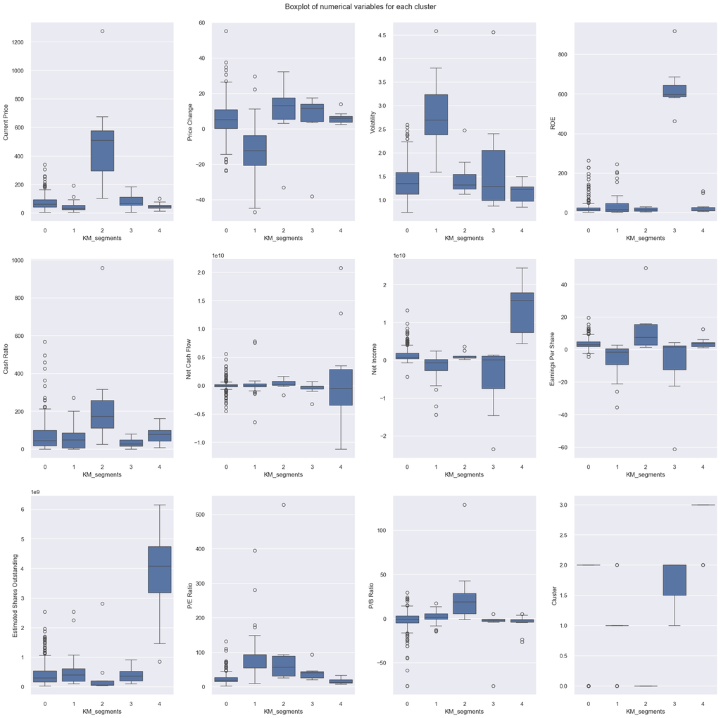

```python
plt.figure(figsize=(20, 20))
plt.suptitle("Boxplot of numerical variables for each cluster")

# selecting numerical columns
num_col = df.select_dtypes(include=np.number).columns.tolist()

for i, variable in enumerate(num_col):
    plt.subplot(3, 4, i + 1)
    sns.boxplot(data=df1, x="KM_segments", y=variable)

plt.tight_layout(pad=2.0)
```

#### Based on the boxplots of numerical variables across each K-Means cluster, the following observations can be made regarding the visual confirmation of each segment's distinct financial characteristics:

#### Feature-Level Observations:

##### Estimated Shares Outstanding: Cluster 4 dominates this metric by an extraordinary margin, with its distribution positioned far above all other clusters. This visual confirmation reinforces the mega-cap nature of this segment — these are not merely profitable companies but structurally massive corporations whose scale of operations is categorically different from the rest of the dataset.

##### P/E and P/B Ratios: Cluster 2 records the highest P/E and P/B ratio distributions, visually confirming its premium growth valuation profile and strong market-to-book premium. Cluster 4 records the lowest P/E distribution, consistent with its characterization as a potentially undervalued large-cap segment. Notably, Clusters 0, 3, and 4 all display negative P/B ratio distributions, with Cluster 3 recording the most deeply negative values — highlighting the unusual and distressed book value situations present in these segments.

## Insights

#### Key Insights and Strategic Conclusions from the K-Means Clustering Analysis

##### Data Quality and Preprocessing: The dataset provides a clean and reliable foundation for analysis, with no missing values or duplicate entries identified during preprocessing. However, the near-universal presence of significant outliers and heavy right-skewness across most numerical features — including Current Price, ROE, Cash Ratio, Net Income, P/E Ratio, P/B Ratio, and Estimated Shares Outstanding — reflects the high degree of financial heterogeneity inherent in stock market data. While the data was appropriately scaled prior to clustering, further specialized outlier treatment — such as winsorization or feature-specific log transformation — may be worth considering in future iterations to improve the robustness of the clustering boundaries, particularly for the smaller and more boundary-adjacent segments.

#### The exploratory data analysis revealed meaningful variation in financial performance across GICS sectors, with the following key patterns:

##### Utilities and Consumer Staples exhibited the lowest average volatility, reinforcing their reputations as defensive, income-oriented sectors that provide portfolio stability.

##### The correlation analysis identified several notable relationships among the financial metrics:

##### Strong positive correlations were observed among profitability metrics — Net Cash Flow, Net Income, and Earnings Per Share — confirming that these variables move in a broadly consistent direction across the dataset.

##### ROE and P/B Ratio also showed a notable positive relationship, reflecting the intuitive link between equity efficiency and market-to-book valuation.

##### Volatility and Cash Ratio exhibited generally weak correlations with most other financial metrics, suggesting that these variables capture dimensions of risk and liquidity that are relatively independent of the profitability and valuation metrics in the dataset — and therefore contribute distinct and non-redundant information to the clustering model.

#### K-Means Cluster Profiles — Five Distinct Investment Archetypes

##### The five-cluster solution successfully identifies a meaningful and interpretable spectrum of market segments, structured as follows:

##### Cluster 0 — The Market Core / Balanced Performers (281 companies — 82.6% of dataset): The dominant segment, representing the standard performance benchmark for the index. With an average price of $73.64, moderate volatility of 1.40, and broadly positive profitability metrics, these companies account for approximately 81.7% of the total net income in the sample. Their broad sectoral diversity — led by Industrials, Financials, Consumer Discretionary, and Health Care — reinforces their role as the stable foundation of the market. The negative average P/B ratio warrants monitoring but does not detract from the segment's overall financial health.

##### Cluster 1 — The High-Volatility Underperformers / Speculative Growth (31 companies): Predominantly driven by Energy sector stocks (22 of 31 companies), this segment is characterized by the highest average volatility (2.77), a significantly negative average price change of approximately -11.76%, and average net losses of approximately -$2.1 billion. These are high-risk, underperforming assets that represent a net drag on total market earnings, and should be approached with considerable caution by risk-averse investors.

##### Cluster 2 — The Elite Premium Growth Stocks (8 companies): A small but highly distinctive segment defined by the highest average share price ($525.42), an extreme average P/E ratio of 113.90, and an exceptionally high average cash ratio of 259.00. Drawing from Consumer Discretionary, Health Care, Information Technology, and Real Estate, these stocks — which include prominent names such as Amazon and Facebook — are valued primarily on the basis of future growth expectations rather than current earnings. They represent compelling opportunities for growth-oriented investors willing to pay a significant premium for quality and long-term potential.

##### Cluster 3 — The Distressed High-Risk / Value Traps (7 companies): The most complex and cautionary segment in the dataset. The exceptionally high average ROE of approximately 633.57 is an accounting artifact of deeply negative book equity rather than genuine operational efficiency, and is accompanied by the most severely negative net income (-$4.9 billion average), the most deeply negative P/B ratio (-11.59), and the lowest cash ratio (33.57) across all segments. These companies exhibit the hallmarks of severe financial distress and represent potential value traps — stocks that may superficially appear efficient due to distorted financial ratios but carry substantial fundamental risk. Extreme caution and thorough due diligence are essential before any investment consideration.

##### Cluster 4 — The Value Titans / Mega-Cap Low P/E Stocks (13 companies): Despite comprising only 13 companies, this segment generates over 36% of the total market profit in the dataset, with an average net income of approximately $14.1 billion. Characterized by the lowest average P/E ratio (16.10), the lowest average volatility (1.16), and the highest estimated shares outstanding (~3.9 billion), these large-cap companies — concentrated in Financials, Health Care, and Telecommunications Services — represent mature, highly profitable, and potentially undervalued investment opportunities ideally suited to value-oriented, risk-averse investors seeking stable long-term returns.

## Hierarchical Clustering

### Computing Cophenetic Correlation

```python
hc_df = subset_scaled_df.copy()
```

```python
# List of common distance metrics
distance_metrics = ['euclidean', 'cityblock', 'chebyshev']

# List of common linkage methods
linkage_methods = ['single', 'complete', 'average', 'ward']

high_cophenet_corr = 0
high_dm_lm = [0, 0]

for dm in distance_metrics:
    for lm in linkage_methods:
        # Note: 'ward' linkage only supports 'euclidean' distance in SciPy
        if lm == 'ward' and dm != 'euclidean':
            continue

        Z = linkage(hc_df, metric=dm, method=lm)
        c, coph_dists = cophenet(Z, pdist(hc_df, metric=dm))

        print(
            "Cophenetic correlation for {} distance and {} linkage is {}.".format(
                dm.capitalize(), lm, c
            )
        )
        if high_cophenet_corr < c:
            high_cophenet_corr = c
            high_dm_lm[0] = dm
            high_dm_lm[1] = lm

# Printing the results
print('*'*100)
print(
    "Highest cophenetic correlation is {}, which is obtained with {} distance and {} linkage.".format(
        high_cophenet_corr, high_dm_lm[0].capitalize(), high_dm_lm[1]
    )
)
```

```
Cophenetic correlation for Euclidean distance and single linkage is 0.9232271494002923.
Cophenetic correlation for Euclidean distance and complete linkage is 0.787328018658067.
Cophenetic correlation for Euclidean distance and average linkage is 0.9422540609560814.
Cophenetic correlation for Euclidean distance and ward linkage is 0.7101180299865353.
Cophenetic correlation for Cityblock distance and single linkage is 0.900820866402081.
Cophenetic correlation for Cityblock distance and complete linkage is 0.7538265604443349.
Cophenetic correlation for Cityblock distance and average linkage is 0.9260523489034486.
Cophenetic correlation for Chebyshev distance and single linkage is 0.8936221223625009.
Cophenetic correlation for Chebyshev distance and complete linkage is 0.6115913526188475.
Cophenetic correlation for Chebyshev distance and average linkage is 0.9444580894762943.
Highest cophenetic correlation is 0.9444580894762943, which is obtained with Chebyshev distance and average linkage.
```

### Let's explore different linkage methods with Euclidean distance only.

```python
# List of linkage methods
linkage_methods = ['single', 'complete', 'average', 'ward']

high_cophenet_corr = 0
high_dm_lm = [0, 0]

for lm in linkage_methods:
    Z = linkage(hc_df, metric="euclidean", method=lm)
    c, coph_dists = cophenet(Z, pdist(hc_df, metric='euclidean'))

    print("Cophenetic correlation for {} linkage is {}.".format(lm, c))

    if high_cophenet_corr < c:
        high_cophenet_corr = c
        high_dm_lm[0] = "euclidean"
        high_dm_lm[1] = lm

# Printing the combination with the highest cophenetic correlation
print('*'*100)
print(
    "Highest cophenetic correlation is {}, which is obtained with {} linkage.".format(
        high_cophenet_corr, high_dm_lm[1]
    )
)
```

```
Cophenetic correlation for single linkage is 0.9232271494002923.
Cophenetic correlation for complete linkage is 0.787328018658067.
Cophenetic correlation for average linkage is 0.9422540609560814.
Cophenetic correlation for ward linkage is 0.7101180299865353.
Highest cophenetic correlation is 0.9422540609560814, which is obtained with average linkage.
```

### Let's view the dendrograms for the different linkage methods with Euclidean distance.

## Checking Dendrograms

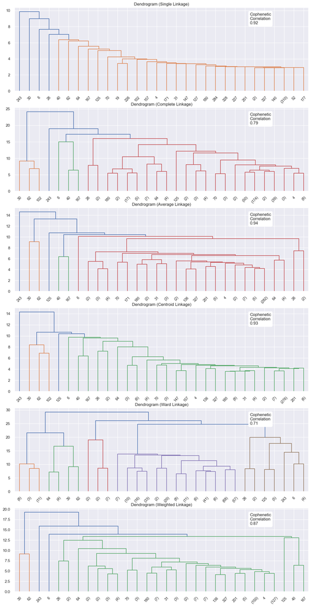

```python
# list of linkage methods
linkage_methods = ['single', 'complete', 'average', 'centroid', 'ward', 'weighted']

# lists to save results of cophenetic correlation calculation
compare_cols = ["Linkage", "Cophenetic Coefficient"]
compare = []

# to create a subplot image
fig, axs = plt.subplots(len(linkage_methods), 1, figsize=(15, 30))

# Enumerate through the list of linkage methods
for i, method in enumerate(linkage_methods):
    Z = linkage(hc_df, metric="euclidean", method=method)

    # Plotting truncated dendrogram for readability
    dendrogram(Z, ax=axs[i], truncate_mode='lastp', p=30)
    axs[i].set_title(f"Dendrogram ({method.capitalize()} Linkage)")

    # Calculate cophenetic correlation
    coph_corr, coph_dist = cophenet(Z, pdist(hc_df))
    axs[i].annotate(
        f"Cophenetic\nCorrelation\n{coph_corr:0.2f}",
        (0.80, 0.80),
        xycoords="axes fraction",
        bbox=dict(boxstyle="round", fc="w")
    )

    compare.append([method, coph_corr])
```

#### Based on the comparison of linkage methods and the interpretation of the resulting dendrograms, the following observations can be made:

##### Centroid Linkage (0.93) — Strong Runner-Up: Centroid linkage performs closely behind average linkage, focusing on the geometric center of each cluster as the basis for distance computation. While its cophenetic correlation of 0.93 confirms strong distance preservation, it is marginally less reliable than average linkage and can occasionally produce inversions in the dendrogram — where a merger appears at a lower height than a previous one — which can complicate interpretation.

##### Single Linkage (0.92) — Strong but Prone to Chaining: Single linkage also records a high cophenetic correlation of 0.92, indicating strong overall distance preservation. However, the dendrograms produced by this method frequently exhibit a pronounced chaining effect — where the algorithm progressively picks off individual outlier stocks one by one rather than forming cohesive, well-defined groups. This behavior can make single linkage dendrograms visually difficult to interpret and less suitable for identifying meaningful cluster boundaries in financial data.

##### Ward Linkage (0.71) — Weakest Performer: Despite producing the most visually balanced and evenly sized clusters — making it a popular choice for general-purpose clustering applications — Ward linkage records the lowest cophenetic correlation of 0.71, indicating the highest degree of distortion relative to the original pairwise distances. This suggests that Ward linkage is not well-suited to preserving the true hierarchical structure of this specific stock dataset, likely because the underlying data does not conform to the spherical, similarly sized cluster geometry that Ward linkage implicitly assumes.

##### Cophenetic Correlation and Dendrogram Fidelity: The average linkage method with Euclidean distance yields the highest cophenetic correlation of approximately 0.94, confirming that its dendrogram is the most faithful visual representation of the actual distances between data points. This makes it the most reliable basis for identifying the hierarchical structure of the stock dataset.

```python
# Create and display the sorted DataFrame
df_cc = pd.DataFrame(compare, columns=compare_cols)
df_cc = df_cc.sort_values(by="Cophenetic Coefficient", ascending=False)

print(df_cc)
```

```
    Linkage  Cophenetic Coefficient
2   average                0.942254
3  centroid                0.931401
0    single                0.923227
5  weighted                0.869378
1  complete                0.787328
4      ward                0.710118
```

#### Based on the hierarchical clustering analysis, the following final insights and key takeaways can be drawn regarding the comparative performance of the linkage methods evaluated:

##### Single Linkage — Strong but Limited by Chaining (0.9232): Despite its high cophenetic correlation, single linkage is prone to the chaining effect — where the algorithm progressively absorbs individual outlier stocks one by one rather than forming cohesive cluster groups. While this behavior contributes to its strong distance-preservation score, it limits the practical interpretability of the resulting dendrogram for financial cluster analysis, making it a less preferable choice than average linkage despite its competitive correlation score.

##### Complete Linkage — Moderate Performance with Notable Distortion (0.7873): Complete linkage records a moderate cophenetic correlation of 0.7873, reflecting a meaningful degree of distortion relative to the original pairwise distances. While it tends to produce more compact and spherical clusters than single linkage, its sensitivity to outliers — which can cause premature merging of distantly related stocks — reduces its suitability for this dataset relative to the top-performing methods.

##### Ward Linkage — Popular but Least Suitable Here (0.7101): Ward linkage records the lowest cophenetic correlation of 0.7101, confirming that it introduces the highest degree of distortion into the true hierarchical relationships of the stocks in this dataset. While Ward linkage is widely used in practice due to its tendency to produce visually balanced and evenly sized clusters, this advantage comes at a significant cost in terms of distance fidelity for this specific financial dataset. The performance gap between Ward linkage (0.7101) and the top three methods (all above 0.92) is substantial and provides clear evidence that Ward linkage is not well-suited to the structure of this data — likely because the heavily skewed, outlier-rich financial metrics do not conform to the spherical, similarly sized cluster geometry that Ward linkage implicitly assumes.

### Creating model using sklearn

```python
# Defining the hierarchical clustering model
HCmodel = AgglomerativeClustering(n_clusters=3, metric="euclidean", linkage="average")

# Fitting the model to the scaled data
HCmodel.fit(hc_df)
```

```
AgglomerativeClustering(linkage='average', n_clusters=3)
```

```python
# creating a copy of the original data
df2 = df.copy()

# adding hierarchical cluster labels to the original and scaled dataframes
hc_df["HC_segments"] = HCmodel.labels_
df2["HC_segments"] = HCmodel.labels_
```

### Cluster Profiling

```python
# Grouping the data by the hierarchical cluster labels to see the average profile of each cluster
hc_cluster_profile = df2.groupby("HC_segments").mean(numeric_only=True)

# Display the resulting profiles
print(hc_cluster_profile)
```

```
             Current Price  Price Change  Volatility         ROE  Cash Ratio  \
HC_segments
0                77.653642      4.184271    1.515129   35.103858    69.79822
1              1274.949951      3.190527    1.268340   29.000000   184.00000
2                24.485001    -13.351992    3.482611  802.000000    51.00000

             Net Cash Flow    Net Income  Earnings Per Share  \
HC_segments
0             6.866225e+07  1.613509e+09            2.900905
1            -1.671386e+09  2.551360e+09           50.090000
2            -1.292500e+09 -1.910650e+10          -41.815000

             Estimated Shares Outstanding  P/E Ratio  P/B Ratio   Cluster
HC_segments
0                            5.789304e+08  32.466828  -1.739711  1.821958
1                            5.093552e+07  25.453183  -1.052429  0.000000
2                            5.195740e+08  60.748608   1.565141  1.000000
```

#### Based on the mean values calculated for each hierarchical cluster, the following segment profiles can be defined:

##### Cluster 0 — The Market Core (337 stocks): By far the largest segment, accounting for 337 of the 340 stocks in the dataset — approximately 99.1% of the total. With an average current price of approximately 77 dollars, moderate volatility, and a healthy average net income of $1.6 billion, this cluster provides the broadest and most representative picture of typical market behavior in the dataset. The financial metrics of this segment are broadly consistent with the baseline profile established in the earlier K-Means analysis, confirming that the vast majority of stocks in the dataset exhibit broadly average and stable financial characteristics.

##### Cluster 1 — The High-Value Outlier — PCLN (1 stock): This cluster consists of a single stock — PCLN (Priceline Group) — whose extreme average current price of approximately $1,275 sets it apart from every other stock in the dataset by a significant margin. Despite its exceptional price level, this stock records a high EPS of 50.09 and relatively lower volatility, confirming that its elevated price reflects genuine and substantial earnings power rather than speculative overvaluation. The isolation of this stock into its own cluster by the hierarchical algorithm underscores just how structurally distinct its price profile is relative to the rest of the market, and validates the algorithm's sensitivity in detecting individual extreme outliers.

##### Cluster 2 — The Distressed High-Volatility Outliers (2 stocks): This cluster comprises just two stocks, characterized by a low average current price of approximately 24.49 dollars , exceptionally high average volatility of 3.48 — the highest across all three clusters — and massive average net losses of approximately -$19.1 billion, accompanied by negative EPS. These metrics collectively identify these two stocks as severely financially distressed outliers whose extreme loss profiles and price volatility place them in a category entirely distinct from the market core. Their isolation into a separate cluster confirms that the hierarchical algorithm has successfully detected and separated these high-risk, loss-making stocks from the broader market population.

```python
hc_cluster_profile["count_in_each_segment"] = (
    df2.groupby("HC_segments")["Ticker Symbol"].count().values
)
```

```python
hc_cluster_profile.style.highlight_max(color="lightgreen", axis=0)
```

| HC_segments | Current Price | Price Change | Volatility | ROE | Cash Ratio | Net Cash Flow | Net Income | Earnings Per Share | Estimated Shares Outstanding | P/E Ratio | P/B Ratio | Cluster | count_in_each_segment |
| --- | --- | --- | --- | --- | --- | --- | --- | --- | --- | --- | --- | --- | --- |
| 0 | 77.653642 | 4.184271 | 1.515129 | 35.103858 | 69.798220 | 68662246.290801 | 1613508620.178041 | 2.900905 | 578930419.447478 | 32.466828 | -1.739711 | 1.821958 | 337 |
| 1 | 1274.949951 | 3.190527 | 1.268340 | 29.000000 | 184.000000 | -1671386000.000000 | 2551360000.000000 | 50.090000 | 50935516.070000 | 25.453183 | -1.052429 | 0.000000 | 1 |
| 2 | 24.485001 | -13.351992 | 3.482611 | 802.000000 | 51.000000 | -1292500000.000000 | -19106500000.000000 | -41.815000 | 519573983.250000 | 60.748608 | 1.565141 | 1.000000 | 2 |

#### Based on the hierarchical cluster profile analysis, the following observations can be made regarding the defining characteristics of each of the three identified segments:

##### Cluster 0 — The Diverse Mainstream Market Core (337 companies): This is by far the largest segment, accounting for 337 of the 340 stocks in the dataset — approximately 99.1% of the total — and representing the broad baseline of typical market behavior. Companies in this cluster exhibit moderate current prices, moderately positive price changes of approximately 4.18%, and moderate volatility, alongside broadly positive and healthy financial metrics across ROE, Cash Ratio, Net Cash Flow, Net Income, and EPS. The cluster also records the highest average estimated shares outstanding of approximately 5.79 × 10⁸, confirming that it contains many large companies by share count, and the strongest aggregate net income and net cash flow figures across all three clusters. The negative average P/B ratio warrants attention, suggesting that on average these companies may be carrying accumulated losses or holding book values below their market values — a nuance consistent with the findings from the earlier K-Means analysis for a similarly defined market core segment. Overall, this cluster captures the broad and diverse mainstream of the dataset — companies that do not exhibit the extreme financial characteristics that define the two outlier clusters.

##### Cluster 1 — The Extremely High-Priced Outlier (1 company): This cluster consists of a single stock — identified as PCLN (Priceline Group) — whose exceptionally high current price of 1,274.95 places it in an entirely separate category from every other stock in the dataset. Despite its extreme price level, the stock records low volatility and a very high EPS of 50.09, confirming that its elevated valuation reflects genuine and substantial earnings power rather than speculative interest. The very high cash ratio of 184.00 further highlights an exceptionally strong liquidity position. However, the notably negative net cash flow of approximately -$1.67 billion — despite strong earnings — suggests significant investment activity, capital expenditure, or other cash outflows that produce an interesting divergence between reported earnings and actual cash generation. The negative P/B ratio is also noteworthy and may reflect share buyback activity or specific accounting structures. Overall, this stock's isolation into its own cluster by the hierarchical algorithm powerfully validates the sensitivity of the method in detecting structurally extreme individual outliers.

##### Cluster 2 — The Highly Volatile Underperformers / Value Traps (2 companies): This very small cluster comprises just two stocks, representing the most severely distressed and high-risk segment in the dataset. Key characteristics include the highest average volatility of 3.48, the most negative average price change of -13.35%, the most severely negative average net income of approximately -$19.1 billion, and the most negative average EPS of -41.82 — collectively painting a picture of extreme financial distress and poor recent market performance. The exceptionally high average ROE of 802.00 is almost certainly a distortion driven by deeply negative book equity rather than genuine operational efficiency — a pattern directly consistent with the value trap profile identified for the analogous distressed cluster in the earlier K-Means analysis. The high average P/E ratio of approximately 60.75 is similarly distorted by negative earnings rather than reflective of genuine growth expectations. The positive P/B ratio stands in contrast to the negative P/B values observed in Clusters 0 and 1, and may reflect residual speculative market interest in these stocks despite their severely impaired fundamentals.

```python
# Complete the code to print the companies in each cluster
for cl in df2["HC_segments"].unique():
    print("In cluster {}, the following companies are present:".format(cl))
    print(df2[df2["HC_segments"] == cl]["Security"].unique())
    print()
```

```
In cluster 0, the following companies are present:
['American Airlines Group' 'AbbVie' 'Abbott Laboratories'
 'Adobe Systems Inc' 'Analog Devices, Inc.' 'Archer-Daniels-Midland Co'
 'Alliance Data Systems' 'Ameren Corp' 'American Electric Power'
 'AFLAC Inc' 'American International Group, Inc.'
 'Apartment Investment & Mgmt' 'Assurant Inc' 'Arthur J. Gallagher & Co.'
 'Akamai Technologies Inc' 'Albemarle Corp' 'Alaska Air Group Inc'
 'Allstate Corp' 'Allegion' 'Alexion Pharmaceuticals'
 'Applied Materials Inc' 'AMETEK Inc' 'Affiliated Managers Group Inc'
 'Amgen Inc' 'Ameriprise Financial' 'American Tower Corp A'
 'Amazon.com Inc' 'AutoNation Inc' 'Anthem Inc.' 'Aon plc'
 'Anadarko Petroleum Corp' 'Amphenol Corp' 'Arconic Inc'
 'Activision Blizzard' 'AvalonBay Communities, Inc.' 'Broadcom'
 'American Water Works Company Inc' 'American Express Co' 'Boeing Company'
 'Bank of America Corp' 'Baxter International Inc.' 'BB&T Corporation'
 'Bard (C.R.) Inc.' 'Baker Hughes Inc' 'BIOGEN IDEC Inc.'
 'The Bank of New York Mellon Corp.' 'Ball Corp' 'Bristol-Myers Squibb'
 'Boston Scientific' 'BorgWarner' 'Boston Properties' 'Citigroup Inc.'
 'Caterpillar Inc.' 'Chubb Limited' 'CBRE Group'
 'Crown Castle International Corp.' 'Carnival Corp.' 'Celgene Corp.'
 'CF Industries Holdings Inc' 'Citizens Financial Group' 'Church & Dwight'
 'C. H. Robinson Worldwide' 'Charter Communications' 'CIGNA Corp.'
 'Cincinnati Financial' 'Colgate-Palmolive' 'Comerica Inc.'
 'CME Group Inc.' 'Chipotle Mexican Grill' 'Cummins Inc.' 'CMS Energy'
 'Centene Corporation' 'CenterPoint Energy' 'Capital One Financial'
 'Cabot Oil & Gas' 'The Cooper Companies' 'CSX Corp.' 'CenturyLink Inc'
 'Cognizant Technology Solutions' 'Citrix Systems' 'CVS Health'
 'Chevron Corp.' 'Concho Resources' 'Dominion Resources' 'Delta Air Lines'
 'Du Pont (E.I.)' 'Deere & Co.' 'Discover Financial Services'
 'Quest Diagnostics' 'Danaher Corp.' 'The Walt Disney Company'
 'Discovery Communications-A' 'Discovery Communications-C'
 'Delphi Automotive' 'Digital Realty Trust' 'Dun & Bradstreet'
 'Dover Corp.' 'Dr Pepper Snapple Group' 'Duke Energy' 'DaVita Inc.'
 'Devon Energy Corp.' 'eBay Inc.' 'Ecolab Inc.' 'Consolidated Edison'
 'Equifax Inc.' "Edison Int'l" 'Eastman Chemical' 'EOG Resources'
 'Equinix' 'Equity Residential' 'EQT Corporation' 'Eversource Energy'
 'Essex Property Trust, Inc.' 'E*Trade' 'Eaton Corporation'
 'Entergy Corp.' 'Edwards Lifesciences' 'Exelon Corp.' "Expeditors Int'l"
 'Expedia Inc.' 'Extra Space Storage' 'Ford Motor' 'Fastenal Co'
 'Facebook' 'Fortune Brands Home & Security' 'Freeport-McMoran Cp & Gld'
```

[output cut: 58 more lines]

```
 'Valero Energy' 'Vulcan Materials' 'Vornado Realty Trust'
 'Verisk Analytics' 'Verisign Inc.' 'Vertex Pharmaceuticals Inc'
 'Ventas Inc' 'Verizon Communications' 'Waters Corporation'
 'Wec Energy Group Inc' 'Wells Fargo' 'Whirlpool Corp.'
 'Waste Management Inc.' 'Williams Cos.' 'Western Union Co'
 'Weyerhaeuser Corp.' 'Wyndham Worldwide' 'Wynn Resorts Ltd'
 'Cimarex Energy' 'Xcel Energy Inc' 'XL Capital' 'Exxon Mobil Corp.'
 'Dentsply Sirona' 'Xerox Corp.' 'Xylem Inc.' 'Yahoo Inc.'
 'Yum! Brands Inc' 'Zimmer Biomet Holdings' 'Zions Bancorp' 'Zoetis']

In cluster 2, the following companies are present:
['Apache Corporation' 'Chesapeake Energy']

In cluster 1, the following companies are present:
['Priceline.com Inc']
```

#### The hierarchical clustering analysis has successfully segmented the 340 companies into three distinct groups. The composition and defining characteristics of each cluster can be observe as as follows:

##### Cluster 0 — The Diverse Mainstream Market Core (337 companies): The largest cluster by a considerable margin, encompassing 337 of the 340 companies in the dataset and representing the broad baseline of typical market behavior. Companies in this cluster exhibit moderate current prices, positive average price changes, and moderate volatility, alongside generally profitable financial metrics across ROE, Cash Ratio, Net Cash Flow, Net Income, and EPS. The negative average P/B ratio suggests that some companies within this group may carry accumulated losses or hold book values below their market values — consistent with the findings from the earlier cluster profile analysis. This cluster captures the vast and diverse mainstream of the dataset, spanning a wide range of sectors and financial profiles, and serves as the generalized reference group against which the two outlier clusters are most meaningfully compared.

##### Cluster 1 — The Extremely High-Priced Outlier — Priceline.com Inc. (1 company): This cluster consists of a single company — Priceline.com Inc. — whose exceptionally high current price, very high earnings per share of 50.09, and strong cash ratio of 184.00 collectively identify it as a structurally unique and financially robust outlier. Despite these strong fundamental indicators, the company records a negative net cash flow and a negative P/B ratio, suggesting the presence of significant investment activity or capital outflows that create an interesting divergence between reported earnings and actual cash generation. The isolation of Priceline.com into its own cluster by the hierarchical algorithm powerfully demonstrates the method's sensitivity in detecting and separating individual extreme outliers from the broader market population — an outcome that would not have been achievable through a coarser clustering approach.

##### Cluster 2 — The Highly Volatile Underperformers / Value Traps — Apache Corporation and Chesapeake Energy (2 companies): This very small cluster comprises just two companies — Apache Corporation and Chesapeake Energy — both of which exhibit the hallmarks of severe financial distress and high market risk. Their defining characteristics include very low current prices, significantly negative price changes, and the highest average volatility of 3.48 across all three clusters — collectively indicating poor recent performance and an elevated risk profile. The exceptionally high average ROE is almost certainly a distortion caused by deeply negative book equity rather than genuine operational efficiency, and is accompanied by severely negative net income and EPS, and a high P/E ratio inflated by negative earnings. This combination of distorted financial ratios and extreme losses is a classic signature of a value trap — a stock that may superficially appear efficient or attractively valued based on isolated metrics, but whose underlying financial condition is severely impaired. The identification of these two energy sector companies as a distinct cluster is consistent with the earlier finding that the Energy sector is disproportionately represented among the highest-risk and worst-performing stocks in the dataset.

```python
df2.groupby(["HC_segments", "GICS Sector"])['Security'].count()
```

```
HC_segments  GICS Sector
0            Consumer Discretionary         39
             Consumer Staples               19
             Energy                         28
             Financials                     49
             Health Care                    40
             Industrials                    53
             Information Technology         33
             Materials                      20
             Real Estate                    27
             Telecommunications Services     5
             Utilities                      24
1            Consumer Discretionary          1
2            Energy                          2
Name: Security, dtype: int64
```

#### Based on the breakdown of GICS sectors within each hierarchical cluster, the following observations can be made regarding the sectoral composition of each segment:

##### Cluster 0 — The Diverse Mainstream Market Core (337 companies): As the largest and most broadly representative cluster, Cluster 0 draws membership from virtually all sectors in the dataset. The most prominent contributors are Industrials (53 companies), Financials (49 companies), Health Care (40 companies), and Consumer Discretionary (39 companies), collectively accounting for a substantial proportion of the cluster's total membership. The Energy sector also maintains a notable presence with 28 companies — though it is worth highlighting that the two most severely distressed Energy stocks, Apache Corporation and Chesapeake Energy, have been successfully isolated into Cluster 2, meaning the Energy representation within Cluster 0 reflects the more stable and moderately performing companies within that sector. The broad and balanced cross-sector distribution of this cluster is entirely consistent with its characterization as the generalized mainstream market group.

##### Cluster 1 — The Extremely High-Priced Outlier (1 company — Consumer Discretionary): The single company in this cluster — Priceline.com Inc. — belongs to the Consumer Discretionary sector. This sectoral classification is consistent with Priceline's business model as a premium online travel and booking platform, where high earnings power, strong brand value, and significant pricing leverage combine to produce the exceptional per-share earnings and elevated market price that distinguish it from all other stocks in the dataset. The presence of a Consumer Discretionary company as the dataset's most extreme high-price outlier also aligns with the earlier bivariate analysis, which identified Consumer Discretionary as one of the sectors most commonly associated with high-growth, high-valuation stock profiles.

##### Cluster 2 — The Highly Volatile Underperformers / Value Traps (2 companies — Energy): Both companies in this cluster — Apache Corporation and Chesapeake Energy — belong exclusively to the Energy sector. This finding powerfully reinforces the recurring pattern identified across multiple stages of this analysis: the Energy sector is disproportionately represented among the highest-risk, worst-performing, and most financially distressed stocks in the dataset. The exclusive Energy composition of Cluster 2, combined with the sector's dominant presence in the analogous high-volatility underperformer cluster identified during the K-Means analysis, confirms that Energy sector distress is not an isolated phenomenon limited to one or two individual stocks, but reflects a broader sectoral pattern of financial strain and market underperformance during the observed period.

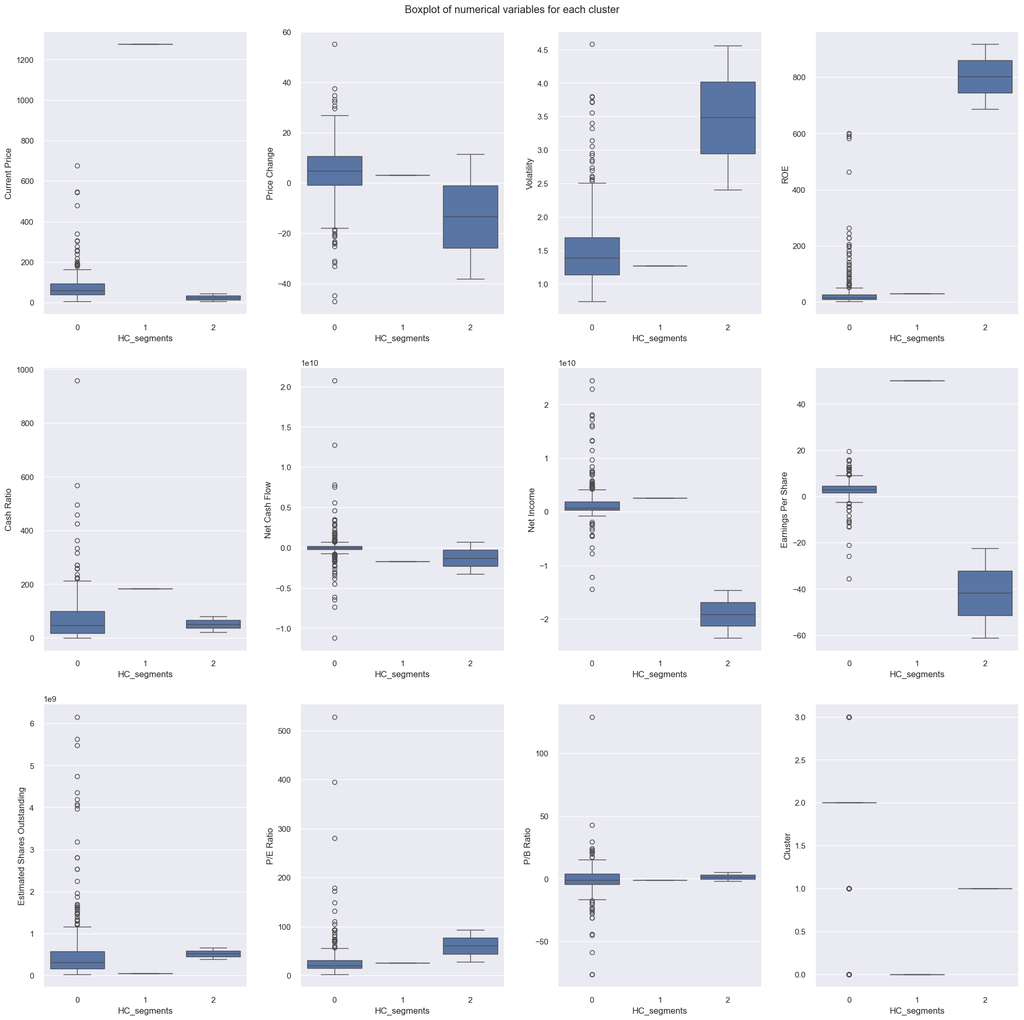

```python
plt.figure(figsize=(20, 20))
plt.suptitle("Boxplot of numerical variables for each cluster")

for i, variable in enumerate(num_col):
    plt.subplot(3, 4, i + 1)
    sns.boxplot(data=df2, x="HC_segments", y=variable)

plt.tight_layout(pad=2.0)
```

#### Based on the boxplots of numerical variables across each hierarchical cluster, the following observations can be made regarding the visual confirmation of each segment's distinct financial characteristics:

##### Current Price: Cluster 1 — the single high-value outlier — stands out unambiguously, with a current price of $1,274.95 that sits far above the distributions of both other clusters. Cluster 0 records a moderate price distribution consistent with its mainstream market profile, while Cluster 2 displays the lowest median current price across all three segments — reflecting the depressed valuations of the two severely distressed stocks.

##### Price Change: Cluster 2 displays a distribution centered distinctly below zero, providing clear visual confirmation of its underperformer profile and negative price momentum. Clusters 0 and 1 both record distributions primarily above zero, with Cluster 0 reflecting moderate positive price changes across its broad mainstream membership and Cluster 1 reflecting modest positive movement despite its extreme price level.

##### Volatility: Cluster 2 exhibits the highest and most widely spread volatility distribution across all three segments, with both a higher median and a broader range — visually confirming its high-risk, high-instability profile. Cluster 1 records comparatively low volatility, consistent with the stable and earnings-supported nature of Priceline.com's price profile. Cluster 0 sits in the moderate middle range, reflecting the broadly average risk level of the mainstream market core.

### K-means vs Hierarchical Clustering

#### Comparative Analysis: K-Means Clustering vs. Hierarchical Clustering

##### The hierarchical model effectively absorbed the majority of the more specialized K-Means clusters — including the High-Volatility Underperformers, Premium Growth Stocks, and Value Titans — into a single large mainstream group, separating only the two most extreme outliers. This suggests that while K-Means identifies meaningful gradations of financial performance within the mainstream market, HC treats all but the most structurally anomalous stocks as broadly equivalent — a useful perspective for outlier detection but a limiting one for granular market segmentation.

##### Appropriate Number of Clusters

##### K-Means: Five clusters was determined as the optimal cluster count based on the Elbow Method and Silhouette Score analysis, capturing the meaningful variance across a broader spectrum of market archetypes — from the Market Core and High-Volatility Underperformers to the Elite Premium Growth Stocks, Distressed Value Traps, and Value Titans.

##### Hierarchical Clustering: Three clusters emerged as the most appropriate structure based on the Cophenetic Correlation Coefficient analysis (0.94 for average linkage), cleanly separating the broad mainstream market from the high-priced individual outlier (Priceline.com) and the pair of distressed high-volatility stocks (Apache Corporation and Chesapeake Energy).

## Actionable Insights, Conclusion, and Recommendations

### Actionable Insights

#### Based on the comprehensive exploratory data analysis and the K-Means and Hierarchical clustering analyses, the following key insights can be drawn:

##### Cluster 3 — The Distressed Value Traps (7 companies): Characterized by a distorted and artificially high ROE driven by negative book equity, significant net losses, and the lowest cash ratio across all segments. These companies require rigorous due diligence before any investment consideration.

##### Cluster 4 — The Value Titans / Large-Cap Low P/E Stocks (13 companies): Large, highly profitable, and financially stable companies with the lowest average volatility and P/E ratio across all segments — potentially attractive to value-oriented, risk-averse investors seeking stable long-term returns.

##### 5. Hierarchical Clustering — Three Segments with Precise Outlier Isolation

##### The Hierarchical Clustering analysis excelled at isolating structurally extreme outliers, providing critical identification of highly unusual and distressed assets:

##### Cluster 0 — The Diverse Mainstream (337 companies): The dominant cluster representing the broad population of stocks with broadly average financial characteristics.

##### Cluster 1 — The Extremely High-Priced Outlier — Priceline.com Inc. (1 company): Uniquely isolated due to its exceptionally high current price, EPS, and cash ratio — marking it as a significant structural anomaly despite its strong earnings profile.

##### Cluster 2 — The Highly Volatile Underperformers / Value Traps — Apache Corporation and Chesapeake Energy (2 companies): Two severely distressed Energy sector companies, clearly separated from the mainstream population by their extreme losses, highest volatility, and severely impaired financial ratios.

### Conclusion

##### The clustering analysis successfully segmented the stock dataset into meaningful and interpretable groups, providing a structured and data-driven understanding of the companies based on their financial and market characteristics. The two methodologies — K-Means and Hierarchical Clustering — proved to be complementary rather than competing approaches, each contributing distinct and valuable analytical perspectives.

##### K-Means delivered a richer and more granular segmentation of the mainstream market, identifying five distinct investment archetypes that support targeted portfolio strategy development across a range of risk appetites and return objectives. Hierarchical Clustering, by contrast, offered superior precision in isolating structurally extreme outliers — cleanly separating the most anomalous stocks from the broad market population with a high degree of fidelity to the true pairwise distance structure of the data.

##### Together, the two approaches provide a more complete and robust analytical framework than either method could deliver in isolation — K-Means defining the broad market landscape and Hierarchical Clustering pinpointing the most structurally distinctive individual observations within it. The identified clusters are distinct, interpretable, and consistent across both methodologies, offering a solid and reliable foundation for informed investment decision-making.

### Recommendations

#### 1. Tailored Investment Strategies

##### Value investors should consider K-Means Cluster 4 (Value Titans / Large-Cap Low P/E Stocks), which combines exceptional profitability with conservative earnings multiples and low volatility.

##### Risk-averse investors are best served by sectors with historically low volatility — such as Utilities and Consumer Staples — or by companies within K-Means Cluster 4.

##### Investors should avoid or heavily scrutinize companies in K-Means Cluster 1 (High-Volatility Underperformers), K-Means Cluster 3 (Distressed Value Traps), and Hierarchical Cluster 2 (Apache Corporation and Chesapeake Energy), given their high-risk profiles and severely impaired financial fundamentals.

#### 2. Outlier Management and Preprocessing Refinement

##### Given the prevalence of significant outliers across most numerical features, further investigation into specialized outlier treatment methods — such as Winsorization, feature-specific log transformation, or robust scaling — could improve cluster compactness and boundary separation in future iterations of the model. A dedicated analysis of the specific outliers isolated by Hierarchical Clustering may also yield valuable insights into unique business models, sector-specific market events, or structural accounting anomalies that warrant further investigation.

#### 3. Dynamic and Periodic Re-Clustering

##### Stock market conditions are continuously evolving, and the financial profiles of individual companies can shift significantly over relatively short periods. Implementing a dynamic clustering framework — whereby the model is periodically retrained on updated financial data — would ensure that the segmentation remains relevant, accurate, and actionable over time, reflecting the current state of the market rather than a historical snapshot.

#### 4. Integration of External and Macroeconomic Factors

##### Future iterations of this analysis could be enriched by incorporating external economic indicators, industry-specific developments, macroeconomic trends, and sentiment data alongside the internal financial metrics currently used. Such an expanded feature set would provide a more holistic and contextually grounded view of stock performance and cluster dynamics, potentially improving both the interpretability and the predictive utility of the resulting segmentation.